# Comparative Genomics Southern Flounder

```r
source("lib/libraries.R")
source("lib/ggplot.R")
source("lib/VCFfilterstats.R")
source("lib/HaplotypR.R")

knitr::opts_chunk$set(warning = FALSE, message = FALSE)
```

# Read Mapping

Map each library to optimized *de novo* reference by transfering copy of `reference.fasta` and associated files for K1 = 2 and K2 = 1 into each directory containing demultiplexed and quality trimmed `fastq`-files.

```
cd /home/soleary/FLOUNDER/REF/REF21
cp reference.fasta* /home/soleary/FLOUNDER/SEQUENCES/SFL-1
cp reference.fasta* /home/soleary/FLOUNDER/SEQUENCES/SFL-FamB
```

Run `dDocent` from within each library directory to map reads to `reference.fasta`. Change mapping parameters for BWA to:

- Mapping Match_Value: 1
- Mapping Mismatch_Value: 3
- Mapping GapOpen_Penalty: 5

Run dDocent separately for each mapping family:

```
cd /home/soleary/FLOUNDER/SEQUENCES/SFL-1
dDocent

cd /home/soleary/FLOUNDER/SEQUENCES/SFL-FamB
dDocent
```

# Variant Calling

Call SNPs for each mapping family separately.

```
cd /home/soleary/FLOUNDER/SEQUENCES/SFL-1
dDocent

cd /home/soleary/FLOUNDER/SEQUENCES/SFL-2
dDocent
```

File `TotalRawSNPs.vcf` contains all raw SNP/INDEL calls.

# SNP Filtering

Filter and haplotyping resulting SNP data sets separately for Fam-A and Fam-B.

Bash script `scr/other/VCF_Filtering.sh` contains commands to use `vcftools` to run through a variety of options and combinations of threshold values for quality, allowed missing data, minor alleles etc. The number of SNPs and individuals retained at each step is recorded in the spreadsheet `data/VCF/FilterStats.xls` to help select appropriate filtering steps and final threshold values.

## Family A

For *Family-A* HiSeq data mapped to MiSeq reference generated using all individuals in library.

### Prepare SNP data set for filtering

dDocent uses FreeBayes to call SNPs and write a VCF-file `TotalRawSNPs.vcf`. This data set was filtered to remove low quality and artefactual SNP sites, paralogs and low quality individuals based on levels of missing data, minimum/maximum read depth, genotype call rate, and minor allele frequencies. Contigs may contain more than one SNP; the script `rad_haplotyper.pl` was used to create haplotypes for each locus.

Generate a list of all individuals included in the SNP data set called by FreeBayes in the dDocent pipeline.

```
cd /home/soleary/FLOUNDER/SEQUENCES/SFL-1
vcfsamplenames TotalRawSNPs.vcf > Ind_RAW
```

Use `VCFtools` to create stats files for depth, missing data, heterozygosity and site quality for the raw data.

```
vcftools --vcf TotalRawSNPs.vcf --out FamA_raw --depth
vcftools --vcf TotalRawSNPs.vcf --out FamA_raw --site-mean-depth
vcftools --vcf TotalRawSNPs.vcf --out FamA_raw --site-quality
vcftools --vcf TotalRawSNPs.vcf --out FamA_raw --missing-indv
vcftools --vcf TotalRawSNPs.vcf --out FamA_raw --missing-site
vcftools --vcf TotalRawSNPs.vcf --out FamA_raw --het
```

Identify low quality individuals by comparing levels of missing data and read depth.

```r
ind_stats_raw <- read.ind.stats(dir = "data/VCF", vcf = "FamA_RAW") %>%
  separate(INDV, into = c("SP", "LIB", "SAMPLE_ID"), sep = "_", remove = FALSE)
```

Mean read depth per individual across all SNP sites, the mean mean depth across all SNP sites is 20.7, the 5th % quantile is 5.1:

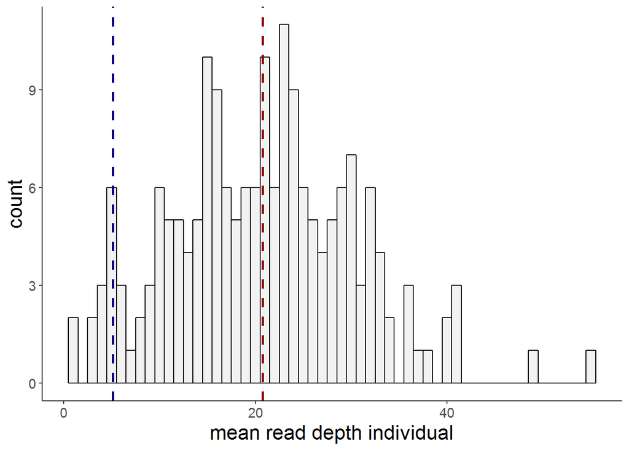

```r
# plot depth distribution
ggplot(ind_stats_raw, aes(x = MEAN_DEPTH_FamA_RAW)) +
  geom_histogram(binwidth = 1, color = "black", fill = "grey95") +
  geom_vline(aes(xintercept = mean(ind_stats_raw$MEAN_DEPTH_FamA_RAW, na.rm = TRUE)),
                 color = "darkred", linetype = "dashed", size = 1) +
  geom_vline(aes(xintercept = quantile(MEAN_DEPTH_FamA_RAW, .05, na.rm = TRUE)),
                 color = "darkblue", linetype = "dashed", size = 1) +
  labs(x = "mean read depth individual") +
  theme_standard
```

Frequency of missing data per individual across all SNP sites; the mean mean depth across all individuals is 0.4060275, the 95th % quantile is 0.709157:

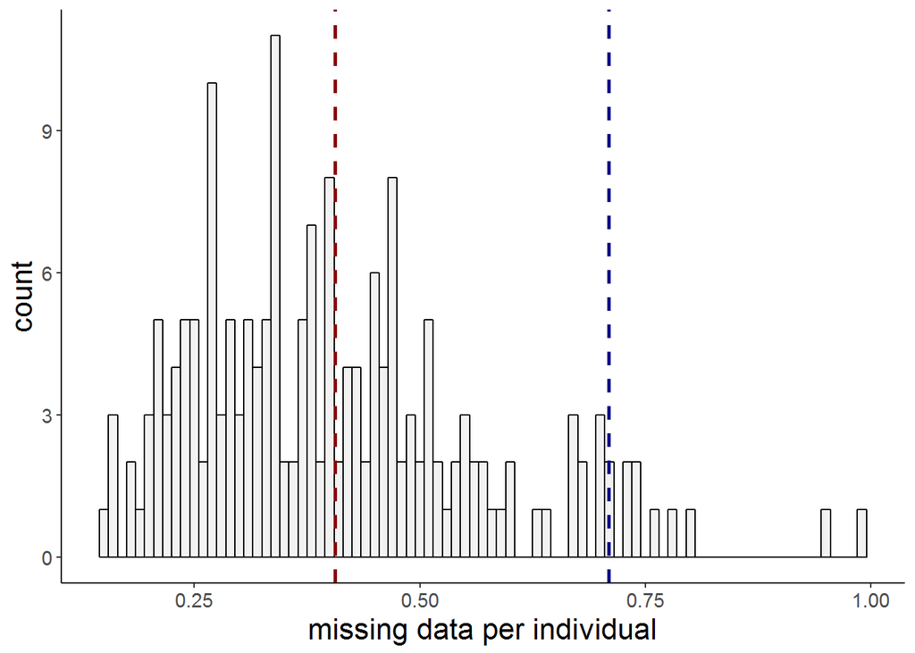

```r
# plot distribution of missing data
ggplot(ind_stats_raw, aes(x = MISS_FamA_RAW)) +
  geom_histogram(binwidth = .01, color = "black", fill = "grey95") +
  geom_vline(aes(xintercept = mean(ind_stats_raw$MISS_FamA_RAW, na.rm = TRUE)),
                 color = "darkred", linetype = "dashed", size = 1) +
  geom_vline(aes(xintercept = quantile(MISS_FamA_RAW, .95)),
                 color = "darkblue", linetype = "dashed", size = 1) +
  labs(x = "missing data per individual") +
  theme_standard
```

Heterozygosity per individual across all SNP sites; the mean values for Fis is 0.2848594, the 95th % quantile is 0.370266 and the 5th % quantile is 0.144152:

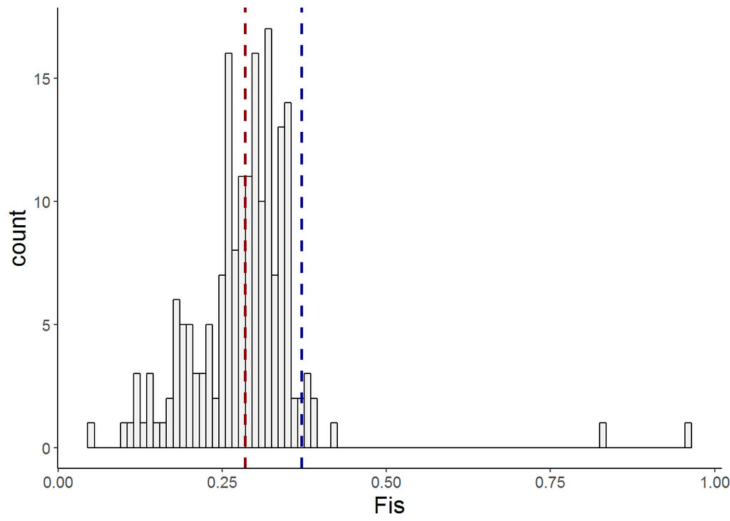

```r
# plot Fis
ggplot(ind_stats_raw, aes(x = Fis_FamA_RAW)) +
  geom_histogram(binwidth = .01, color = "black", fill = "grey95") +
  geom_vline(aes(xintercept = mean(ind_stats_raw$Fis_FamA_RAW, na.rm = TRUE)),
                 color = "darkred", linetype = "dashed", size = 1) +
  geom_vline(aes(xintercept = quantile(Fis_FamA_RAW, .95)),
                 color = "darkblue", linetype = "dashed", size = 1) +
  labs(x = "Fis") +
  theme_standard
```

### Choose threshold values for quality score, coverage, missing data, minor alleles

#### Filter 0: Sequence quality

The QUAL column of a VCF file is a phred based score indicating the probability that the variant shown in the ALT column is wrong. Given the Phred quality score (Q), and the probability that a base is incorrectly called (P), Q = -10(Log10P).

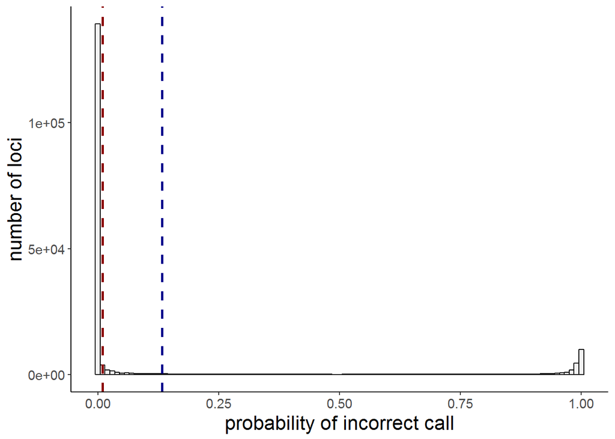

```r
site_qual <- read.table("data/VCF/FamA_raw.lqual",
                        header = TRUE, stringsAsFactors = FALSE) %>%
  mutate(PROB = 10^(-QUAL/10))

# plot distribution of probability that wrong call
ggplot(site_qual, aes(x = PROB)) +
  geom_histogram(binwidth = 0.01, color = "black", fill = "grey95") +
  geom_vline(aes(xintercept = mean(site_qual$PROB, na.rm = TRUE)),
                 color = "darkblue", linetype = "dashed", size = 1) +
  geom_vline(aes(xintercept = 0.01), color = "darkred", linetype = "dashed", size = 1) +
  labs(x = "probability of incorrect call", y = "number of loci") +
  theme_standard
```

A quality score of 20 indicates, a 1 in 100 chance that the SNP site has been called incorrectly (i.e. 99% probability that correct call). Filter loci below minimum quality of 20:

```
vcftools --vcf TotalRawSNPs.vcf --out FamA.F0 --minQ 20 --recode --recode-INFO-all
```

#### Filter 1: genotype call rate & minimum minor allele count

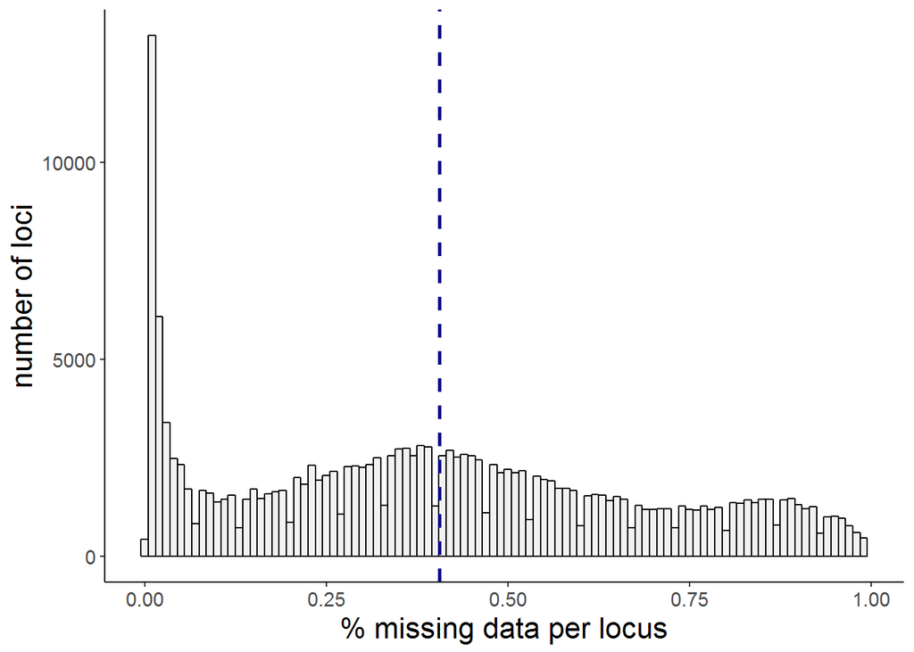

```r
loc_stats_raw <- read.loc.stats(dir = "data/VCF/", vcf = "FamA_raw")

# plot distribution read depth
ggplot(loc_stats_raw, aes(x = MISS_FamA_raw)) +
  geom_histogram(binwidth = 0.01, color = "black", fill = "grey95") +
  geom_vline(aes(xintercept = mean(MISS_FamA_raw, na.rm = TRUE)),
                 color = "darkblue", linetype = "dashed", size = 1) +
  labs(x = "% missing data per locus", y = "number of loci") +
  theme_standard
```

Filter loci with minor allele count < 3 and genotype call rate < 0.5

```
vcftools --vcf FamA.F0.recode.vcf --out FamA.F1 --max-missing 0.5 --mac 3 --recode --recode-INFO-all
```

#### Filter 2: minimum depth per genotype

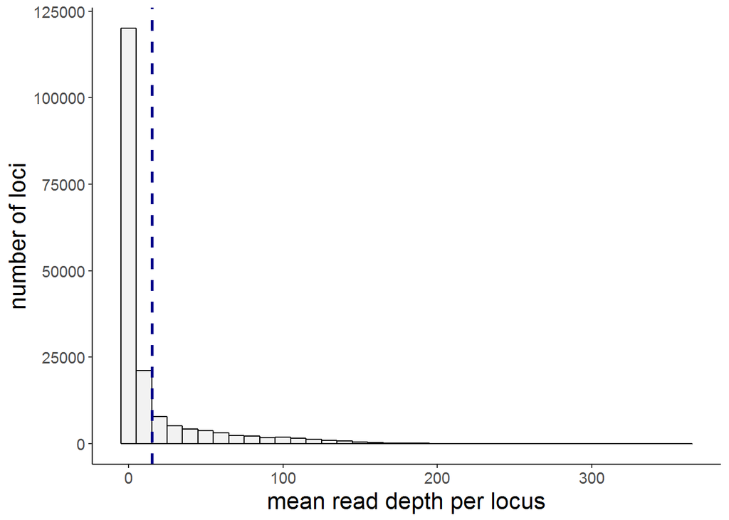

```r
# plot distribution missing data
ggplot(loc_stats_raw, aes(x = MEAN_DEPTH_FamA_raw)) +
  geom_histogram(binwidth = 10, color = "black", fill = "grey95") +
  geom_vline(aes(xintercept = mean(MEAN_DEPTH_FamA_raw, na.rm = TRUE)),
                 color = "darkblue", linetype = "dashed", size = 1) +
  labs(x = "mean read depth per locus", y = "number of loci") +
  theme_standard
```

Code loci with less than 3 reads per locus per individual as missing.

```
vcftools --vcf FamA.F1.recode.vcf --out FamA.F2a --minDP 3 --recode --recode-INFO-all
```

Remove flagged loci.

```
vcftools --vcf FamA.F2a.recode.vcf --out FamA.F2  --max-missing 0.5 --recode --recode-INFO-all
```

Query individual and site stats:

```
vcftools --vcf FamA.F2.recode.vcf --out FamA.F2 --depth
vcftools --vcf FamA.F2.recode.vcf --out FamA.F2 --site-mean-depth
vcftools --vcf FamA.F2.recode.vcf --out FamA.F2 --site-quality
vcftools --vcf FamA.F2.recode.vcf --out FamA.F2 --missing-site
vcftools --vcf FamA.F2.recode.vcf --out FamA.F2 --missing-indv
vcftools --vcf FamA.F2.recode.vcf --out FamA.F2 --het
```

Assess individual quality by comparing levels of missing data and read depth.

```r
ind_stats_F2 <- read.ind.stats(dir = "data/VCF", vcf = "FamA.F2") %>%
  separate(INDV, into = c("SP", "LIB", "SAMPLE_ID"), sep = "_", remove = FALSE)
```

Mean read depth per individual across all SNP sites, the mean mean depth across all SNP sites is 47.8, the 5th % quantile is 6.8:

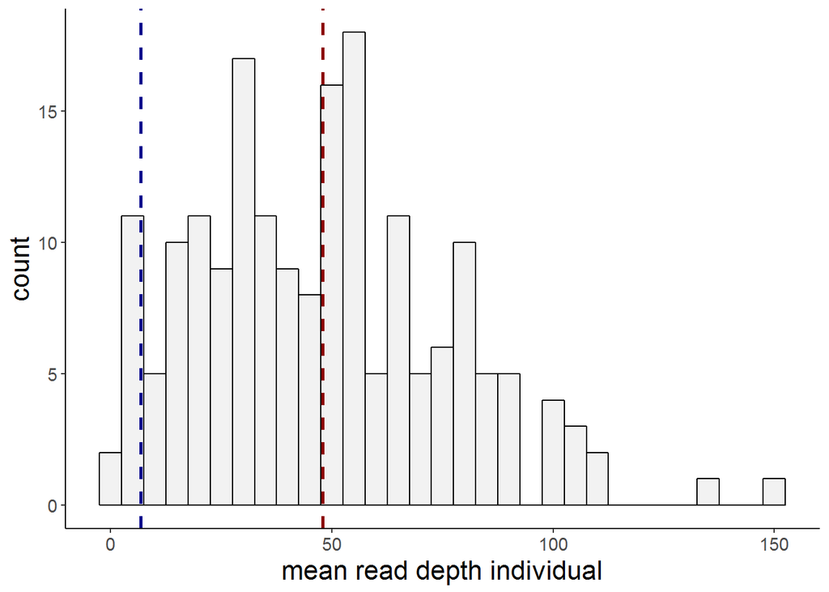

```r
ggplot(ind_stats_F2, aes(x = MEAN_DEPTH_FamA.F2)) +
  geom_histogram(binwidth = 5, color = "black", fill = "grey95") +
  geom_vline(aes(xintercept = mean(ind_stats_F2$MEAN_DEPTH_FamA.F2, na.rm = TRUE)),
                 color = "darkred", linetype = "dashed", size = 1) +
  geom_vline(aes(xintercept = quantile(ind_stats_F2$MEAN_DEPTH_FamA.F2, .05)),
                 color = "darkblue", linetype = "dashed", size = 1) +
  labs(x = "mean read depth individual") +
  theme_standard
```

Frequency of missing data per individual across all SNP sites; the mean mean depth across all individuals is 0.2, the 95th % quantile is 0.5:

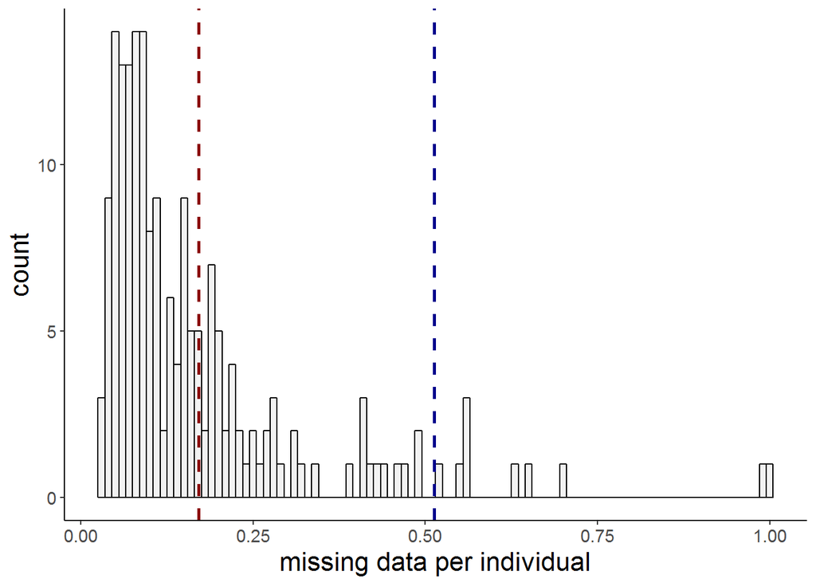

```r
ggplot(ind_stats_F2, aes(x = MISS_FamA.F2)) +
  geom_histogram(binwidth = .01, color = "black", fill = "grey95") +
  geom_vline(aes(xintercept = mean(MISS_FamA.F2, na.rm = TRUE)),
                 color = "darkred", linetype = "dashed", size = 1) +
  geom_vline(aes(xintercept = quantile(MISS_FamA.F2, .95)),
                 color = "darkblue", linetype = "dashed", size = 1) +
  labs(x = "missing data per individual") +
  theme_standard
```

Heterozygosity per individual across all SNP sites; the mean values for Fis is -0.1, the 95th % quantile is -0.1 and the 5th % quantile is -0.2:

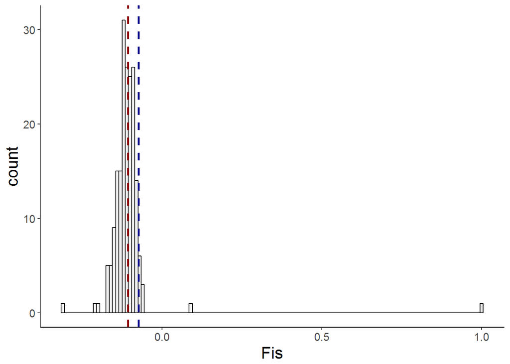

```r
ggplot(ind_stats_F2, aes(x = Fis_FamA.F2)) +
  geom_histogram(binwidth = .01, color = "black", fill = "grey95") +
  geom_vline(aes(xintercept = mean(ind_stats_F2$Fis_FamA.F2, na.rm = TRUE)),
                 color = "darkred", linetype = "dashed", size = 1) +
  geom_vline(aes(xintercept = quantile(ind_stats_F2$Fis_FamA.F2, .95)),
                 color = "darkblue", linetype = "dashed", size = 1) +
  labs(x = "Fis") +
  theme_standard
```

#### Filter 3: missing data (locus/indv) I

Filter loci with genotype call rate < 0.6

```
vcftools --vcf FamA.F2.recode.vcf --out FamA.F3a --max-missing 0.6 --recode --recode-INFO-all
vcftools --vcf FamA.F3a.recode.vcf --out FamA.F3a --missing-indv
```

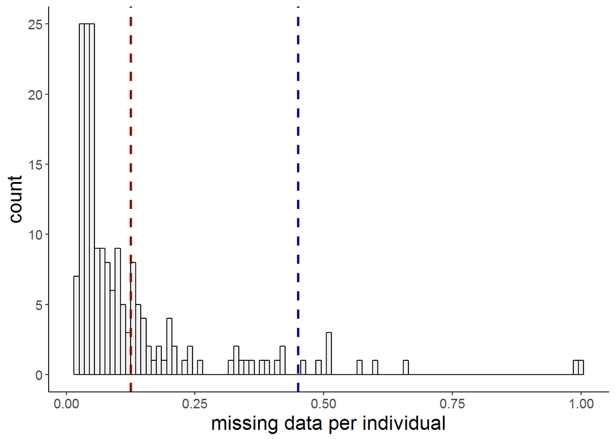

```r
imiss_F3 <- read.table("data/VCF/FamA.F3a.imiss",
                       header = TRUE, stringsAsFactors = FALSE)

ggplot(imiss_F3, aes(x = F_MISS)) +
  geom_histogram(binwidth = .01, color = "black", fill = "grey95") +
  geom_vline(aes(xintercept = mean(F_MISS, na.rm = TRUE)),
                 color = "darkred", linetype = "dashed", size = 1) +
  geom_vline(aes(xintercept = quantile(F_MISS, .95)),
                 color = "darkblue", linetype = "dashed", size = 1) +
  labs(x = "missing data per individual") +
  theme_standard
```

Remove individuals with more than 90% missing data

```
mawk -v x=0.9 '$5 > x' FamA.F3a.imiss | cut -f1 > lowDP.indv
vcftools --vcf FamA.F3a.recode.vcf --remove lowDP.indv --out FamA.F3b --recode --recode-INFO-all
```

#### Filter 4: minor allele frequency, mean minimum depth I

Remove loci with minor allele frequency < 0.01 and mean minimum depth (across all individuals) < 5

```
vcftools --vcf FamA.F3b.recode.vcf --out FamA.F4 --maf 0.01 --min-meanDP 5 --recode --recode-INFO-all
vcftools --vcf FamA.F4.recode.vcf --out FamA.F4 --missing-indv
vcftools --vcf FamA.F4.recode.vcf --out FamA.F4 --missing-site
vcftools --vcf FamA.F4.recode.vcf --out FamA.F4 --depth
vcftools --vcf FamA.F4.recode.vcf --out FamA.F4 --het
```

Assess individual quality by comparing levels of missing data and read depth.

```r
ind_stats_F4 <- read.ind.stats(dir = "data/VCF", vcf = "FamA.F4") %>%
  separate(INDV, into = c("SP", "LIB", "SAMPLE_ID"), sep = "_", remove = FALSE)
```

Mean read depth per individual across all SNP sites, the mean mean depth across all SNP sites is 55.5, the 5th % quantile is 7.5:

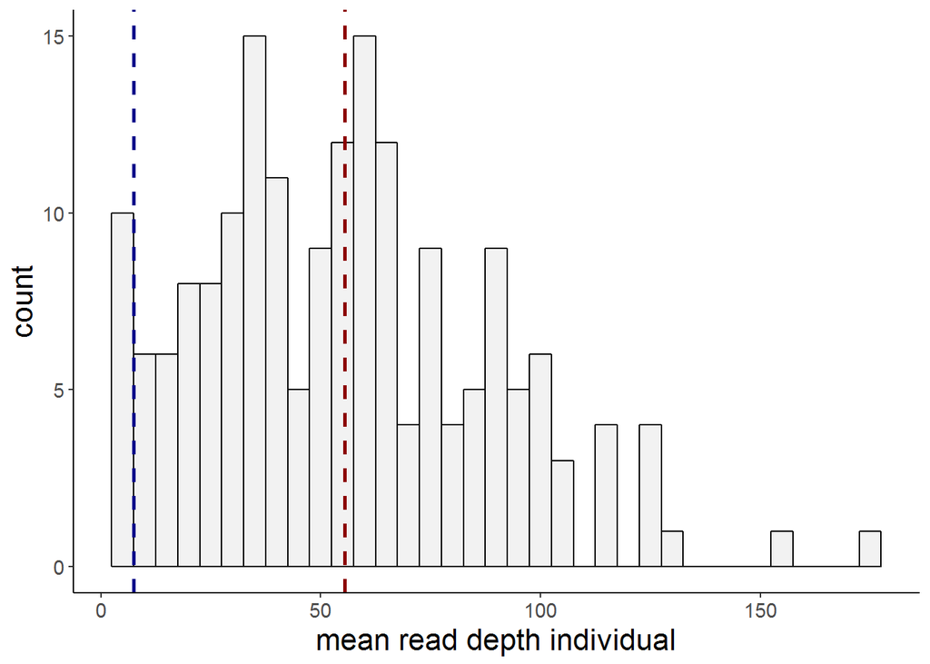

```r
ggplot(ind_stats_F4, aes(x = MEAN_DEPTH_FamA.F4)) +
  geom_histogram(binwidth = 5, color = "black", fill = "grey95") +
  geom_vline(aes(xintercept = mean(ind_stats_F4$MEAN_DEPTH_FamA.F4, na.rm = TRUE)),
                 color = "darkred", linetype = "dashed", size = 1) +
  geom_vline(aes(xintercept = quantile(ind_stats_F4$MEAN_DEPTH_FamA.F4, .05)),
                 color = "darkblue", linetype = "dashed", size = 1) +
  labs(x = "mean read depth individual") +
  theme_standard
```

Frequency of missing data per individual across all SNP sites; the mean mean depth across all individuals is 0.1, the 95th % quantile is 0.4:

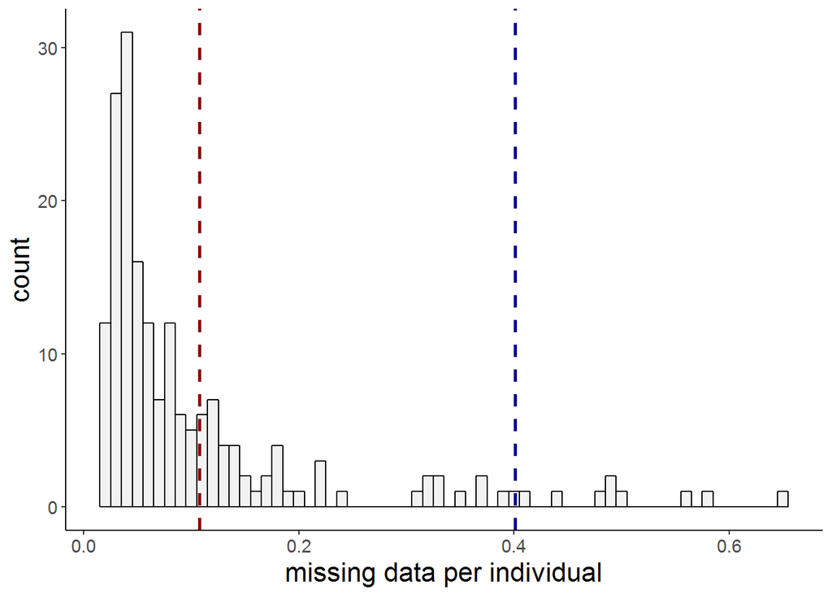

```r
ggplot(ind_stats_F4, aes(x = MISS_FamA.F4)) +
  geom_histogram(binwidth = .01, color = "black", fill = "grey95") +
  geom_vline(aes(xintercept = mean(MISS_FamA.F4, na.rm = TRUE)),
                 color = "darkred", linetype = "dashed", size = 1) +
  geom_vline(aes(xintercept = quantile(MISS_FamA.F4, .95)),
                 color = "darkblue", linetype = "dashed", size = 1) +
  labs(x = "missing data per individual") +
  theme_standard
```

Heterozygosity per individual across all SNP sites; the mean values for Fis is -0.1, the 95th % quantile is -0.1 and the 5th % quantile is -0.2:

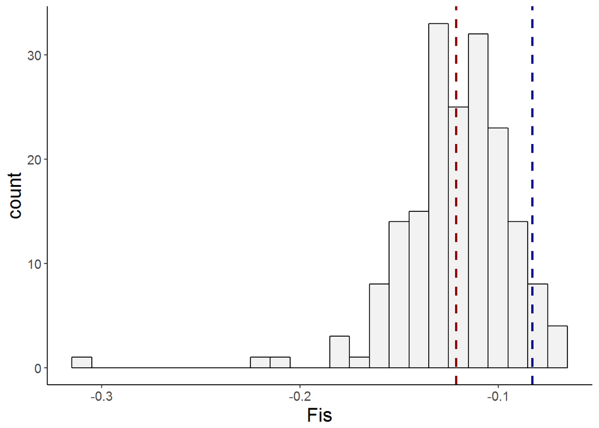

```r
ggplot(ind_stats_F4, aes(x = Fis_FamA.F4)) +
  geom_histogram(binwidth = .01, color = "black", fill = "grey95") +
  geom_vline(aes(xintercept = mean(Fis_FamA.F4, na.rm = TRUE)),
                 color = "darkred", linetype = "dashed", size = 1) +
  geom_vline(aes(xintercept = quantile(Fis_FamA.F4, .95)),
                 color = "darkblue", linetype = "dashed", size = 1) +
  labs(x = "Fis") +
  theme_standard
```

#### Filter 5: missing data (locus/indv) II

Remove loci with genotype call rate < 0.8

```
vcftools --vcf FamA.F4.recode.vcf --out FamA.F5a --max-missing 0.8  --recode --recode-INFO-all
vcftools --vcf FamA.F5a.recode.vcf --out FamA.F5a --missing-indv
```

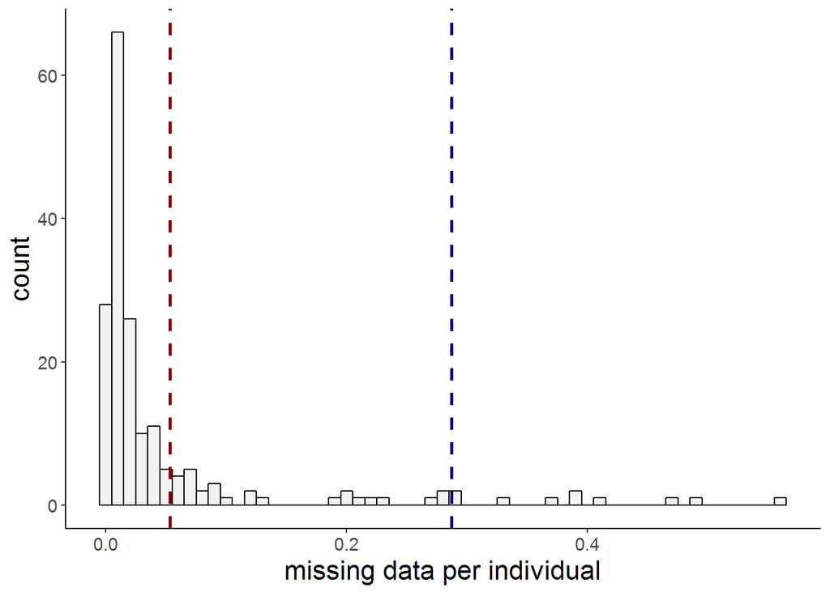

```r
imiss_F5 <- read.table("data/VCF/FamA.F5a.imiss",
                       header = TRUE, stringsAsFactors = FALSE)

ggplot(imiss_F5, aes(x = F_MISS)) +
  geom_histogram(binwidth = .01, color = "black", fill = "grey95") +
  geom_vline(aes(xintercept = mean(F_MISS, na.rm = TRUE)),
                 color = "darkred", linetype = "dashed", size = 1) +
  geom_vline(aes(xintercept = quantile(F_MISS, .95)),
                 color = "darkblue", linetype = "dashed", size = 1) +
  labs(x = "missing data per individual") +
  theme_standard
```

Remove individuals with > 75% missing data

```
mawk -v x=0.75 '$5 > x' FamA.F5a.imiss | cut -f1 > lowDP.indv
vcftools --vcf FamA.F5a.recode.vcf --remove lowDP.indv --recode --recode-INFO-all --out FamA.F5b
```

#### Filter 6: minor allele frequency, mean minimum depth II

```
vcftools --vcf FamA.F5b.recode.vcf --out FamA.F6 --maf 0.03 --recode --recode-INFO-all
vcftools --vcf FamA.F6.recode.vcf --out FamA.F6 --min-meanDP 10
vcftools --vcf FamA.F6.recode.vcf --out FamA.F6 --missing
vcftools --vcf FamA.F6.recode.vcf --out FamA.F6 --depth
vcftools --vcf FamA.F6.recode.vcf --out FamA.F6 --het
vcftools --vcf FamA.F6.recode.vcf --out FamA.F6 --missing-indv
vcftools --vcf FamA.F6.recode.vcf --out FamA.F6 --missing-site
```

Assess individual quality by comparing levels of missing data and read depth.

```r
ind_stats_F6 <- read.ind.stats(dir = "data/VCF", vcf = "FamA.F6") %>%
  separate(INDV, into = c("SP", "LIB", "SAMPLE_ID"), sep = "_", remove = FALSE)
```

Mean read depth per individual across all SNP sites, the mean mean depth across all SNP sites is 66.407434, the 5th % quantile is 8.124754:

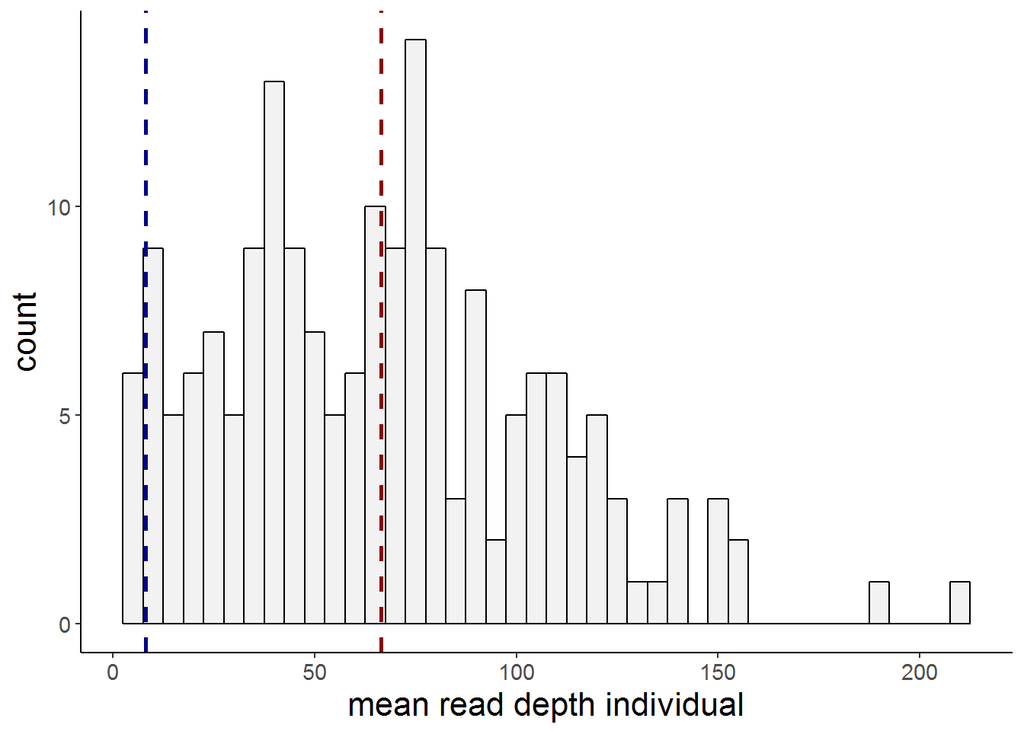

```r
# plot mean read depth per indv
ggplot(ind_stats_F6, aes(x = MEAN_DEPTH_FamA.F6)) +
  geom_histogram(binwidth = 5, color = "black", fill = "grey95") +
  geom_vline(aes(xintercept = mean(MEAN_DEPTH_FamA.F6, na.rm = TRUE)),
                 color = "darkred", linetype = "dashed", size = 1) +
  geom_vline(aes(xintercept = quantile(MEAN_DEPTH_FamA.F6, .05)),
                 color = "darkblue", linetype = "dashed", size = 1) +
  labs(x = "mean read depth individual") +
  theme_standard
```

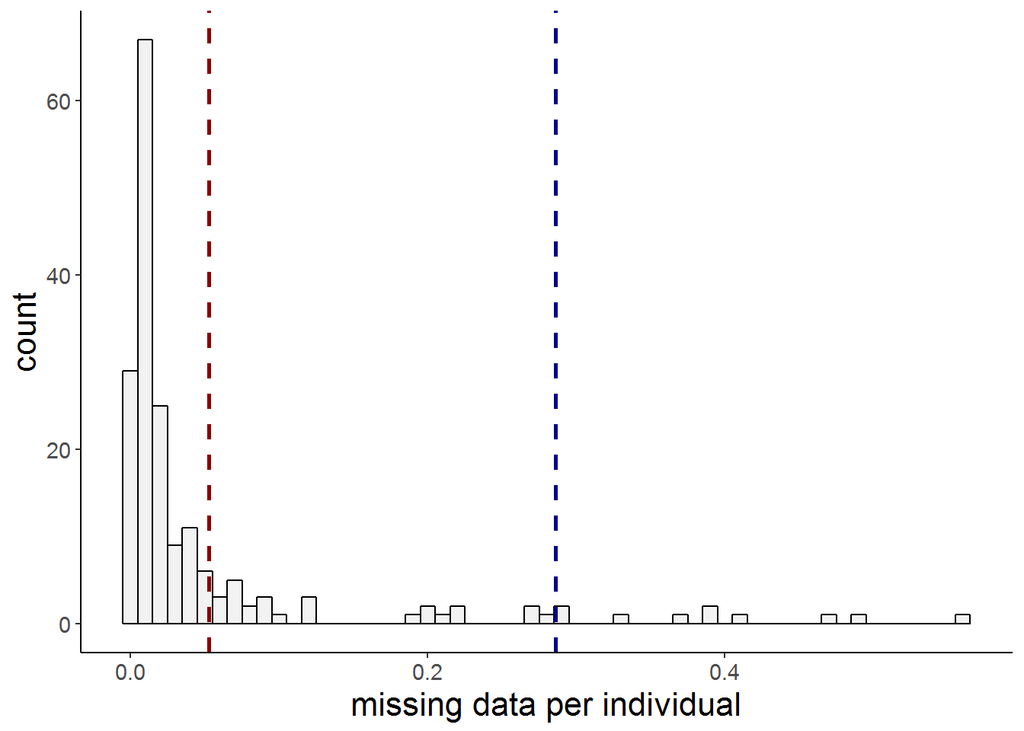

```r
ggplot(ind_stats_F6, aes(x = MISS_FamA.F6)) +
  geom_histogram(binwidth = .01, color = "black", fill = "grey95") +
  geom_vline(aes(xintercept = mean(MISS_FamA.F6, na.rm = TRUE)),
                 color = "darkred", linetype = "dashed", size = 1) +
  geom_vline(aes(xintercept = quantile(MISS_FamA.F6, .95)),
                 color = "darkblue", linetype = "dashed", size = 1) +
  labs(x = "missing data per individual") +
  theme_standard
```

Heterozygosity per individual across all SNP sites; the mean values for Fis is -0.1512066, the 95th % quantile is -0.115929 and the 5th % quantile is -0.189018:

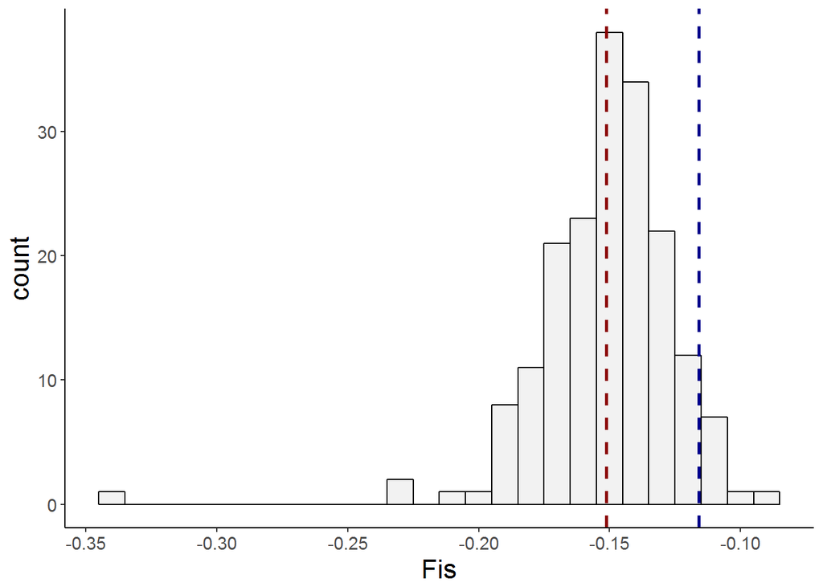

```r
ggplot(ind_stats_F6, aes(x = Fis_FamA.F6)) +
  geom_histogram(binwidth = .01, color = "black", fill = "grey95") +
  geom_vline(aes(xintercept = mean(Fis_FamA.F6, na.rm = TRUE)),
                 color = "darkred", linetype = "dashed", size = 1) +
  geom_vline(aes(xintercept = quantile(Fis_FamA.F6, .95)),
                 color = "darkblue", linetype = "dashed", size = 1) +
  labs(x = "Fis") +
  theme_standard
```

#### Filter 7: missing data (locus/indv) III

```
vcftools --vcf FamA.F6.recode.vcf --out FamA.F7a --max-missing 0.85 --recode --recode-INFO-all
vcftools --vcf FamA.F7a.recode.vcf --out FamA.F7a --missing-indv
```

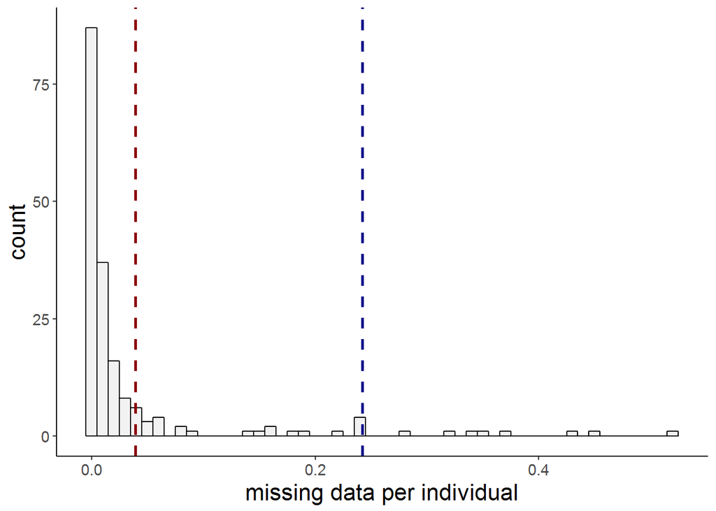

```r
imiss_F7 <- read.table("data/VCF/FamA.F7a.imiss",
                       header = TRUE, stringsAsFactors = FALSE)

ggplot(imiss_F7, aes(x = F_MISS)) +
  geom_histogram(binwidth = .01, color = "black", fill = "grey95") +
  geom_vline(aes(xintercept = mean(F_MISS, na.rm = TRUE)),
                 color = "darkred", linetype = "dashed", size = 1) +
  geom_vline(aes(xintercept = quantile(F_MISS, .95)),
                 color = "darkblue", linetype = "dashed", size = 1) +
  labs(x = "missing data per individual") +
  theme_standard
```

Remove individuals with > 65% missing data.

```
mawk -v x=0.65 '$5 > x' FamA.F7a.imiss | cut -f1 > lowDP.indv
vcftools --vcf FamA.F7a.recode.vcf --remove lowDP.indv --recode --recode-INFO-all --out FamA.F7b
```

#### Filter 8: Ratios of reference/alternate alleles, quality/depth, and mapping quality

```
vcffilter -s -f "AB > 0.2 & AB < 0.8 | AB < 0.01 | AB > 0.99" -s -g "QR > 0 | QA > 0" FamA.F7b.recode.vcf > FamA.F8a.vcf
```

Remove loci with quality/depth ratio < 0.2

```
vcffilter -s -f "QUAL / DP > 0.2" FamA.F8a.vcf > FamA.F8b.vcf
```

Remove loci based on ratio of mapping quality for reference and alternate allele, i.e. sites that have a high discrepancy between the mapping qualities of two alleles.

```
vcffilter -s -f "MQM / MQMR > 0.25 & MQM / MQMR < 1.75" FamA.F8b.vcf > FamA.F8c.vcf
```

Compare number of loci pre/post-filtering

```
mawk '!/#/' FamA.F7b.recode.vcf | wc -l
mawk '!/#/' FamA.F8a.vcf | wc -l
mawk '!/#/' FamA.F8b.vcf | wc -l
mawk '!/#/' FamA.F8c.vcf | wc -l
```

#### Filter 9: Loci with reads from both strands

```
vcffilter -f "SAF / SAR > 100 & SRF / SRR > 100 | SAR / SAF > 100 & SRR / SRF > 50" -s FamA.F8c.vcf > FamA.F9.vcf
```

Compare number of loci pre/post-filtering

```
mawk '!/#/' FamA.F9.vcf | wc -l
```

#### Filter 10: Properly paired status

Identify loci that only unpaired reads mapping to them - an artifact introduced due de novo reference assembly. Compare number of paired reads mapping the reference and the alternate alleles to identify discrepancy in the paired status for reads supporting reference and alternate alleles.

```
vcffilter -f "PAIRED > 0.05 & PAIREDR > 0.05 & PAIREDR / PAIRED < 1.75 & PAIREDR / PAIRED > 0.25 | PAIRED < 0.05 & PAIREDR < 0.05" -s FamA.F9.vcf > FamA.F10.vcf
```

Compare number of loci rep/post-filtering

```
mawk '!/#/' FamA.F10.vcf | wc -l
```

#### Filter 11: Maximum depth

Estimate the original number of individuals in the VCF file (INFO flags in filtered data set are are based on original number of individuals in data set):

```
grep -o -e 'NS=[0-9]*' FamA.F10.vcf | sed s/NS=//g | sort | tail -1
```

Create file with the original site depth and quality score for each site:

```
cut -f8 FamA.F10.vcf | grep -oe "DP=[0-9]*" | sed -s 's/DP=//g' > FamA.F10.DEPTH
mawk '!/#/'  FamA.F10.vcf | cut -f1,2,6 > FamA.F10.loci.qual
```

Calculate average depth and standard deviation:

```
mawk '{ sum += $1; n++ } END { if (n > 0) print sum / n; }' FamA.F10.DEPTH

mawk '{delta = $1 - avg; avg += delta / NR; mean2 += delta * ($1 - avg); } END { print sqrt(mean2 / NR); }' FamA.F10.DEPTH
```

```
paste FamA.F10.loci.qual FamA.F10.DEPTH | mawk -v x=21187.41 '$4 > x'| mawk '$3 < 2 * $4' > FamA.F10.lowQDloci
```

```
vcftools --vcf FamA.F10.vcf --remove-filtered NP --exclude-positions FamA.F10.lowQDloci --site-depth --out FamA.F10
cut -f3 FamA.F10.ldepth > FamA.F10.site.depth
mawk '!/D/' FamA.F10.site.depth | mawk -v x=185 '{print $1/x}' > FamA.meandepthpersite
```

Compare the distribution of mean depth per site averaged across individuals to determine cut-off value of sites with excessively high depth indicative of paralogs/multicopy loci.

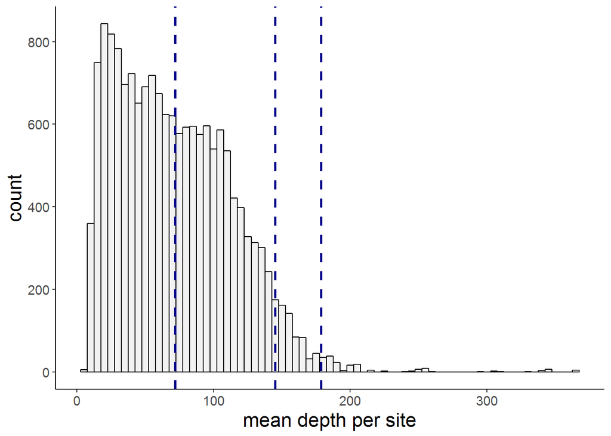

```r
# import mean depth per site
meandepthpersite <- read.table("data/VCF/FamA.meandepthpersite", header = FALSE)

# look at distribution
ggplot(meandepthpersite, aes(x = V1)) +
  geom_histogram(binwidth = 5, color = "black", fill = "grey95") +
  geom_vline(aes(xintercept = mean(V1, na.rm = TRUE)),
                 color = "darkblue", linetype = "dashed", size = 1) +
  geom_vline(aes(xintercept = quantile(meandepthpersite$V1, .95)),
                 color = "darkblue", linetype = "dashed", size = 1) +
  geom_vline(aes(xintercept = quantile(meandepthpersite$V1, .99)),
                 color = "darkblue", linetype = "dashed", size = 1) +
  labs(x = "mean depth per site") +
  theme_standard
```

Choose cut-off value = 250. Combine both depth filters to produce filtered data set.

```
vcftools --vcf  FamA.F10.vcf --max-meanDP 250 --exclude-positions FamA.F10.lowQDloci --recode --recode-INFO-all --out FamA.F11
```

#### Filter 12: Remove Indels

Remove Indels from data set.

```
vcfallelicprimitives FamA.F11.recode.vcf --keep-info --keep-geno > FamA.prim.vcf
vcftools --vcf FamA.prim.vcf --out FamA.F12 --remove-indels --recode --recode-INFO-all
```

#### Filter 13: Minor allele frequency

```
vcftools --vcf FamA.F12.recode.vcf --out FamA.F13 --maf 0.05 --recode --recode-INFO-all
vcftools --vcf FamA.F13.recode.vcf --out FamA.F13 --het
vcftools --vcf FamA.F13.recode.vcf --out FamA.F13 --missing-indv
vcftools --vcf FamA.F13.recode.vcf --out FamA.F13 --missing-site
vcftools --vcf FamA.F13.recode.vcf --out FamA.F13 --depth
```

**Assess individual quality**

Identify low quality individuals by comparing levels of missing data and read depth.

```r
ind_stats_F13 <- read.ind.stats(dir = "data/VCF", vcf = "FamA.F13") %>%
  separate(INDV, into = c("SP", "LIB", "SAMPLE_ID"), sep = "_", remove = FALSE)
```

Mean read depth per individual across all SNP sites, the mean mean depth across all SNP sites is 72.6482674, the 5th % quantile is 8.546843:

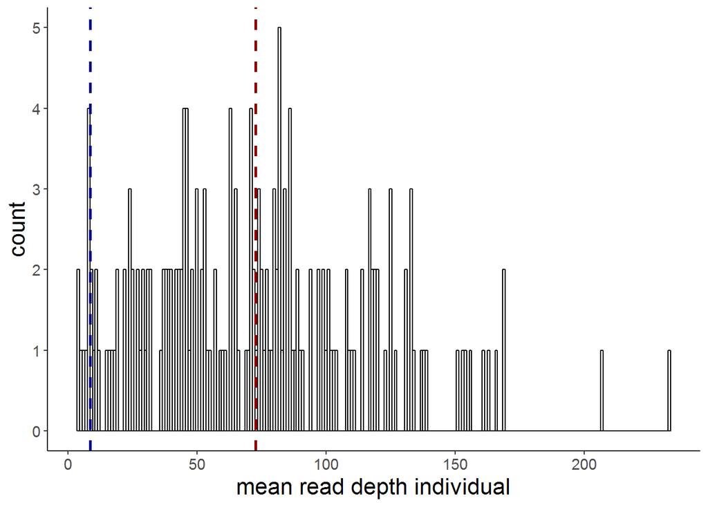

```r
ggplot(ind_stats_F13, aes(x = MEAN_DEPTH_FamA.F13)) +
  geom_histogram(binwidth = 1, color = "black", fill = "grey95") +
  geom_vline(aes(xintercept = mean(MEAN_DEPTH_FamA.F13, na.rm = TRUE)),
                 color = "darkred", linetype = "dashed", size = 1) +
  geom_vline(aes(xintercept = quantile(MEAN_DEPTH_FamA.F13, .05)),
                 color = "darkblue", linetype = "dashed", size = 1) +
  labs(x = "mean read depth individual") +
  theme_standard
```

Frequency of missing data per individual across all SNP sites; the mean mean depth across all individuals is 0.0367658, the 95th % quantile is 0.2335791:

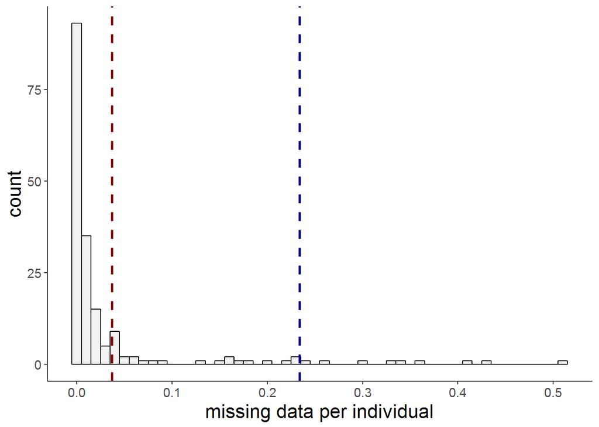

```r
ggplot(ind_stats_F13, aes(x = MISS_FamA.F13)) +
  geom_histogram(binwidth = .01, color = "black", fill = "grey95") +
  geom_vline(aes(xintercept = mean(MISS_FamA.F13, na.rm = TRUE)),
                 color = "darkred", linetype = "dashed", size = 1) +
  geom_vline(aes(xintercept = quantile(MISS_FamA.F13, .95)),
                 color = "darkblue", linetype = "dashed", size = 1) +
  labs(x = "missing data per individual") +
  theme_standard
```

Heterozygosity per individual across all SNP sites; the mean values for Fis is -0.1728997, the 95th % quantile is -0.139194 and the 5th % quantile is -0.206524:

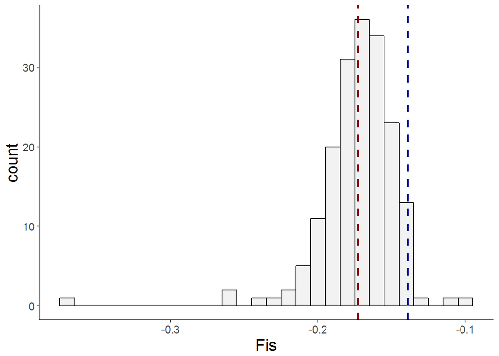

```r
ggplot(ind_stats_F13, aes(x = Fis_FamA.F13)) +
  geom_histogram(binwidth = .01, color = "black", fill = "grey95") +
  geom_vline(aes(xintercept = mean(Fis_FamA.F13, na.rm = TRUE)),
                 color = "darkred", linetype = "dashed", size = 1) +
  geom_vline(aes(xintercept = quantile(Fis_FamA.F13, .95)),
                 color = "darkblue", linetype = "dashed", size = 1) +
  labs(x = "Fis") +
  theme_standard
```

#### Filter 15: Missing data

Set final cut-off for genotype call rate to > 90%.

```
vcftools --vcf FamA.F13.recode.vcf --out FamA.F15a --max-missing 0.9 --recode --recode-INFO-all
vcftools --vcf FamA.F15a.recode.vcf --out FamA.F15a --missing-indv
```

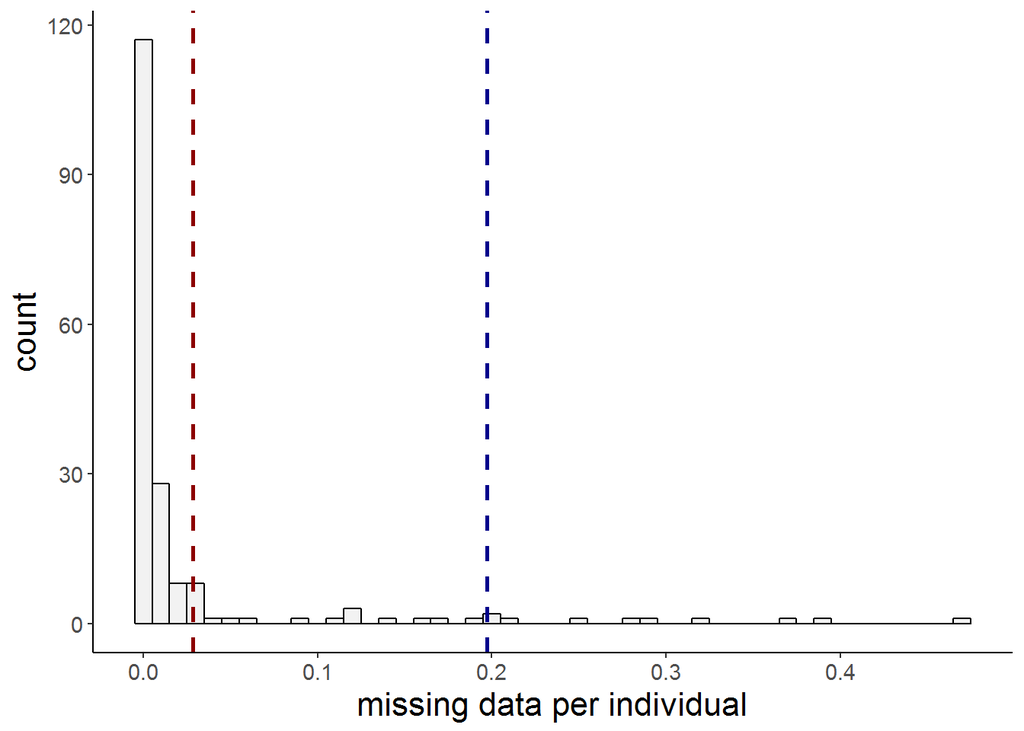

```r
imiss_F15 <- read.table("data/VCF/FamA.F15a.imiss",
                       header = TRUE, stringsAsFactors = FALSE, quote = NULL)

ggplot(imiss_F15, aes(x = F_MISS)) +
  geom_histogram(binwidth = .01, color = "black", fill = "grey95") +
  geom_vline(aes(xintercept = mean(F_MISS, na.rm = TRUE)),
                 color = "darkred", linetype = "dashed", size = 1) +
  geom_vline(aes(xintercept = quantile(F_MISS, .95)),
                 color = "darkblue", linetype = "dashed", size = 1) +
  labs(x = "missing data per individual") +
  theme_standard
```

Set final cut-off for allowable missing data per individual to < 50%.

```
mawk -v x=0.5 '$5 > x' FamA.F15a.imiss | cut -f1 > lowDP.indv
vcftools --vcf FamA.F15a.recode.vcf --out FamA.SNP --remove lowDP.indv --recode --recode-INFO-all

vcftools --vcf FamA.SNP.recode.vcf --out FamA.SNP --missing-indv
vcftools --vcf FamA.SNP.recode.vcf --out FamA.SNP --missing-site
vcftools --vcf FamA.SNP.recode.vcf --out FamA.SNP --site-mean-depth
vcftools --vcf FamA.SNP.recode.vcf --out FamA.SNP --depth
vcftools --vcf FamA.SNP.recode.vcf --out FamA.SNP --het
vcftools --vcf FamA.SNP.recode.vcf --out FamA.SNP --hardy
vcftools --vcf FamA.SNP.recode.vcf --out FamA.SNP --freq
```

## Family B

For *Family-B* HiSeq data mapped to MiSeq reference generated using all individuals in library.

### Prepare SNP data set for filtering

dDocent uses FreeBayes to call SNPs and write a VCF-file `TotalRawSNPs.vcf`. This data set was filtered to remove low quality and artefactual SNP sites, paralogs and low quality individuals based on levels of missing data, minimum/maximum read depth, genotype call rate, and minor allele frequencies. Contigs may contain more than one SNP; the script `rad_haplotyper.pl` was used to create haplotypes for each locus.

Generate a list of all individuals included in the SNP data set called by FreeBayes in the dDocent pipeline.

```
cd /home/soleary/FLOUNDER/SEQUENCES/SFL-FamB
vcfsamplenames TotalRawSNPs.vcf > Ind_RAW
```

Use `VCFtools` to create stats files for depth, missing data, heterozygosity and site quality for the raw data.

```
vcftools --vcf TotalRawSNPs.vcf --out FamB_raw --depth
vcftools --vcf TotalRawSNPs.vcf --out FamB_raw --site-mean-depth
vcftools --vcf TotalRawSNPs.vcf --out FamB_raw --site-quality
vcftools --vcf TotalRawSNPs.vcf --out FamB_raw --missing-indv
vcftools --vcf TotalRawSNPs.vcf --out FamB_raw --missing-site
vcftools --vcf TotalRawSNPs.vcf --out FamB_raw --het
```

Identify low quality individuals by comparing levels of missing data and read depth.

```r
ind_stats_raw <- read.ind.stats(dir = "data/VCF", vcf = "FamB_RAW") %>%
  separate(INDV, into = c("SP", "LIB", "SAMPLE_ID"), sep = "_", remove = FALSE)
```

Mean read depth per individual across all SNP sites, the mean mean depth across all SNP sites is 17.7704659, the 5th % quantile is 4.644428:

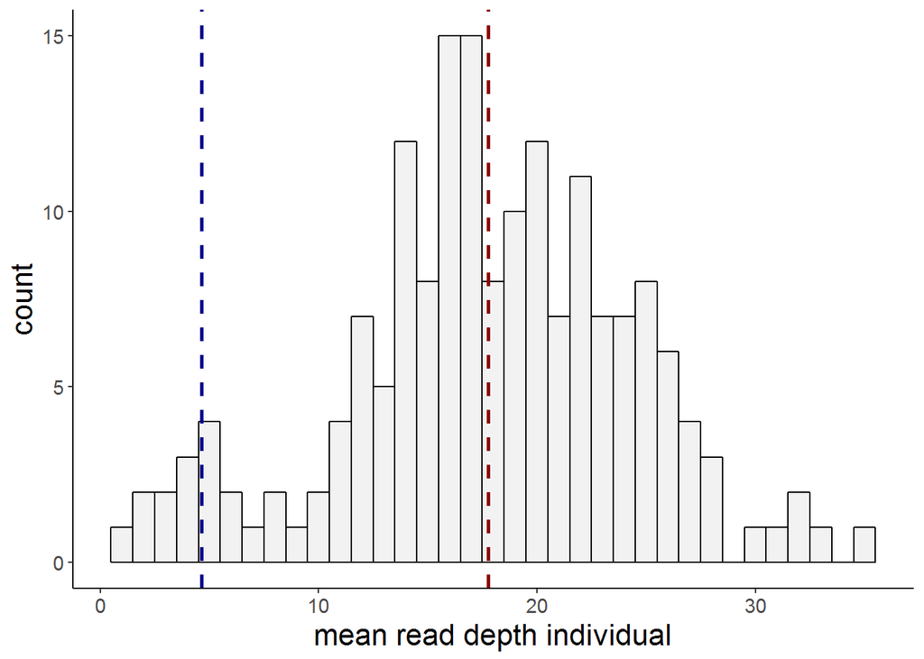

```r
# plot depth distribution
ggplot(ind_stats_raw, aes(x = MEAN_DEPTH_FamB_RAW)) +
  geom_histogram(binwidth = 1, color = "black", fill = "grey95") +
  geom_vline(aes(xintercept = mean(MEAN_DEPTH_FamB_RAW, na.rm = TRUE)),
                 color = "darkred", linetype = "dashed", size = 1) +
  geom_vline(aes(xintercept = quantile(MEAN_DEPTH_FamB_RAW, .05)),
                 color = "darkblue", linetype = "dashed", size = 1) +
  labs(x = "mean read depth individual") +
  theme_standard
```

Frequency of missing data per individual across all SNP sites; the mean mean depth across all individuals is 0.2742126, the 95th % quantile is 0.6402519:

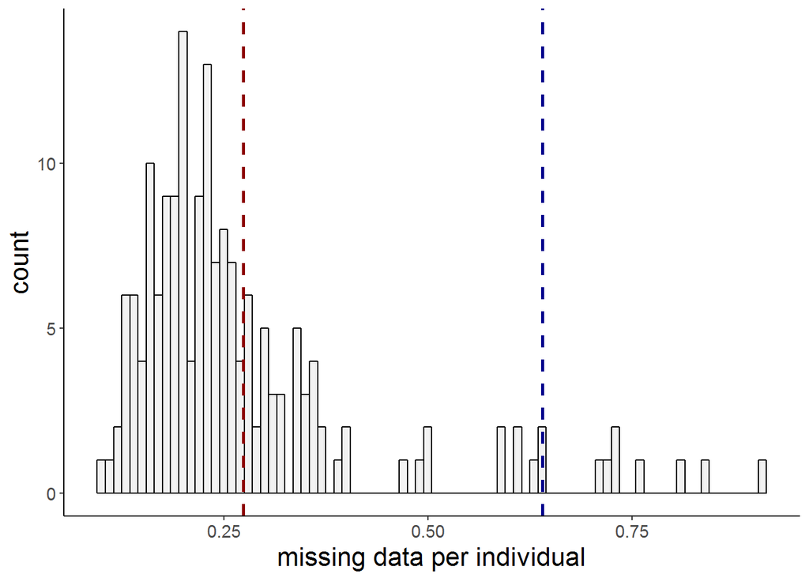

```r
# plot distribution of missing data
ggplot(ind_stats_raw, aes(x = MISS_FamB_RAW)) +
  geom_histogram(binwidth = .01, color = "black", fill = "grey95") +
  geom_vline(aes(xintercept = mean(MISS_FamB_RAW, na.rm = TRUE)),
                 color = "darkred", linetype = "dashed", size = 1) +
  geom_vline(aes(xintercept = quantile(MISS_FamB_RAW, .95)),
                 color = "darkblue", linetype = "dashed", size = 1) +
  labs(x = "missing data per individual") +
  theme_standard
```

Heterozygosity per individual across all SNP sites; the mean values for Fis is 0.1992137, the 95th % quantile is 0.342944 and the 5th % quantile is 0.004105:

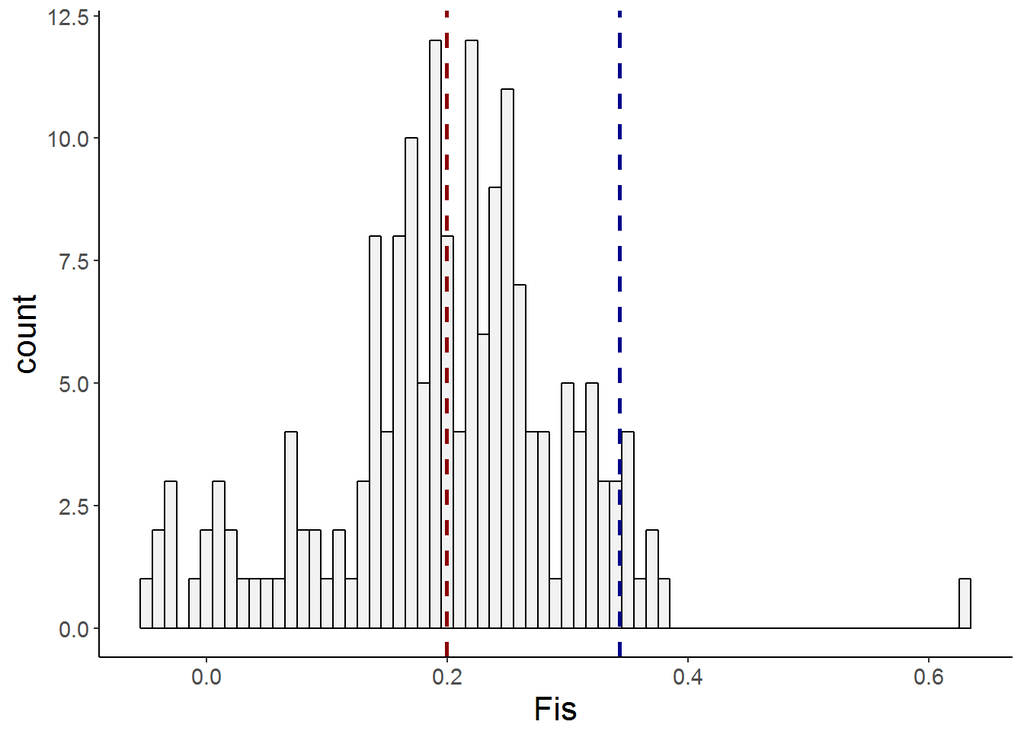

```r
# plot Fis
ggplot(ind_stats_raw, aes(x = Fis_FamB_RAW)) +
  geom_histogram(binwidth = .01, color = "black", fill = "grey95") +
  geom_vline(aes(xintercept = mean(Fis_FamB_RAW, na.rm = TRUE)),
                 color = "darkred", linetype = "dashed", size = 1) +
  geom_vline(aes(xintercept = quantile(Fis_FamB_RAW, .95)),
                 color = "darkblue", linetype = "dashed", size = 1) +
  labs(x = "Fis") +
  theme_standard
```

### Choose threshold values for quality score, coverage, missing data, minor alleles

#### Filter 0: Sequence quality

The QUAL column of a VCF file is a phred based score indicating the probability that the variant shown in the ALT column is wrong. Given the Phred quality score (Q), and the probability that a base is incorrectly called (P), Q = -10(Log10P).

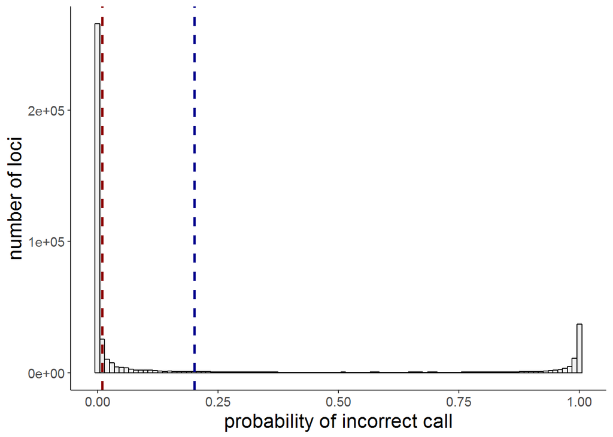

```r
site_qual <- read.table("data/VCF/FamB_raw.lqual",
                        header = TRUE, stringsAsFactors = FALSE) %>%
  mutate(PROB = 10^(-QUAL/10))

# plot distribution of probability that wrong call
ggplot(site_qual, aes(x = PROB)) +
  geom_histogram(binwidth = 0.01, color = "black", fill = "grey95") +
  geom_vline(aes(xintercept = mean(PROB, na.rm = TRUE)),
                 color = "darkblue", linetype = "dashed", size = 1) +
  geom_vline(aes(xintercept = 0.01), color = "darkred", linetype = "dashed", size = 1) +
  labs(x = "probability of incorrect call", y = "number of loci") +
  theme_standard
```

A quality score of 20 indicates, a 1 in 100 chance that the SNP site has been called incorrectly (i.e. 99% probability that correct call). Filter loci below minimum quality of 20:

```
vcftools --vcf TotalRawSNPs.vcf --out FamB.F0 --minQ 20 --recode --recode-INFO-all
```

#### Filter 1: genotype call rate & minimum minor allele count

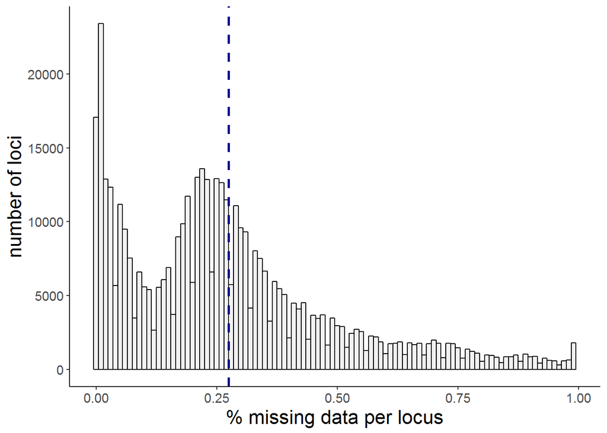

```r
loc_stats_raw <- read.loc.stats(dir = "data/VCF/", vcf = "FamB_raw")

# plot distribution read depth
ggplot(loc_stats_raw, aes(x = MISS_FamB_raw)) +
  geom_histogram(binwidth = 0.01, color = "black", fill = "grey95") +
  geom_vline(aes(xintercept = mean(MISS_FamB_raw, na.rm = TRUE)),
                 color = "darkblue", linetype = "dashed", size = 1) +
  labs(x = "% missing data per locus", y = "number of loci") +
  theme_standard
```

Filter loci with minor allele count < 3 and genotype call rate < 0.5

```
vcftools --vcf FamB.F0.recode.vcf --out FamB.F1 --max-missing 0.5 --mac 3 --recode --recode-INFO-all
```

#### Filter 2: minimum depth per genotype

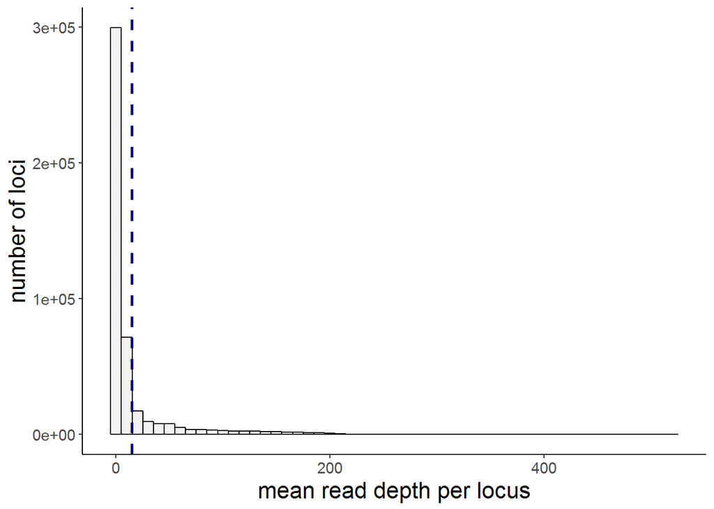

```r
# plot distribution missing data
ggplot(loc_stats_raw, aes(x = MEAN_DEPTH_FamB_raw)) +
  geom_histogram(binwidth = 10, color = "black", fill = "grey95") +
  geom_vline(aes(xintercept = mean(MEAN_DEPTH_FamB_raw, na.rm = TRUE)),
                 color = "darkblue", linetype = "dashed", size = 1) +
  labs(x = "mean read depth per locus", y = "number of loci") +
  theme_standard
```

Code loci with less than 3 reads per locus per individual as missing.

```
vcftools --vcf FamB.F1.recode.vcf --out FamB.F2a --minDP 3 --recode --recode-INFO-all
```

Remove flagged loci.

```
vcftools --vcf FamB.F2a.recode.vcf --out FamB.F2  --max-missing 0.5 --recode --recode-INFO-all
```

Query individual and site stats:

```
vcftools --vcf FamB.F2.recode.vcf --out FamB.F2 --depth
vcftools --vcf FamB.F2.recode.vcf --out FamB.F2 --site-mean-depth
vcftools --vcf FamB.F2.recode.vcf --out FamB.F2 --site-quality
vcftools --vcf FamB.F2.recode.vcf --out FamB.F2 --missing-site
vcftools --vcf FamB.F2.recode.vcf --out FamB.F2--missing-indv
vcftools --vcf FamB.F2.recode.vcf --out FamB.F2 --het
```

Assess individual quality by comparing levels of missing data and read depth.

```r
ind_stats_F2 <- read.ind.stats(dir = "data/VCF", vcf = "FamB.F2") %>%
  separate(INDV, into = c("SP", "LIB", "SAMPLE_ID"), sep = "_", remove = FALSE)
```

Mean read depth per individual across all SNP sites, the mean mean depth across all SNP sites is 36.9665026, the 5th % quantile is 6.635576:

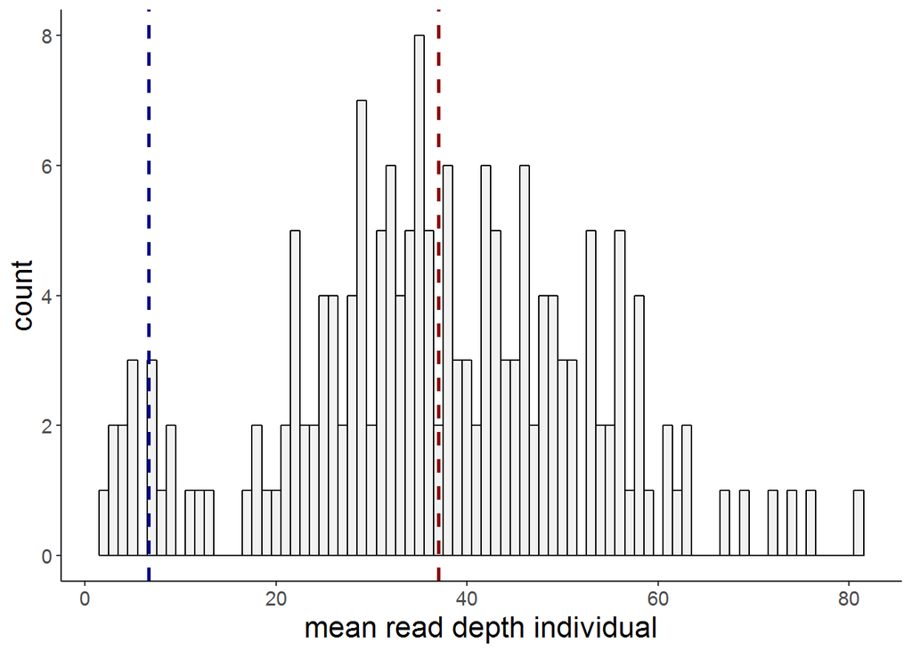

```r
ggplot(ind_stats_F2, aes(x = MEAN_DEPTH_FamB.F2)) +
  geom_histogram(binwidth = 1, color = "black", fill = "grey95") +
  geom_vline(aes(xintercept = mean(MEAN_DEPTH_FamB.F2, na.rm = TRUE)),
                 color = "darkred", linetype = "dashed", size = 1) +
  geom_vline(aes(xintercept = quantile(MEAN_DEPTH_FamB.F2, .05)),
                 color = "darkblue", linetype = "dashed", size = 1) +
  labs(x = "mean read depth individual") +
  theme_standard
```

Frequency of missing data per individual across all SNP sites; the mean mean depth across all individuals is 0.2168408, the 95th % quantile is NA:

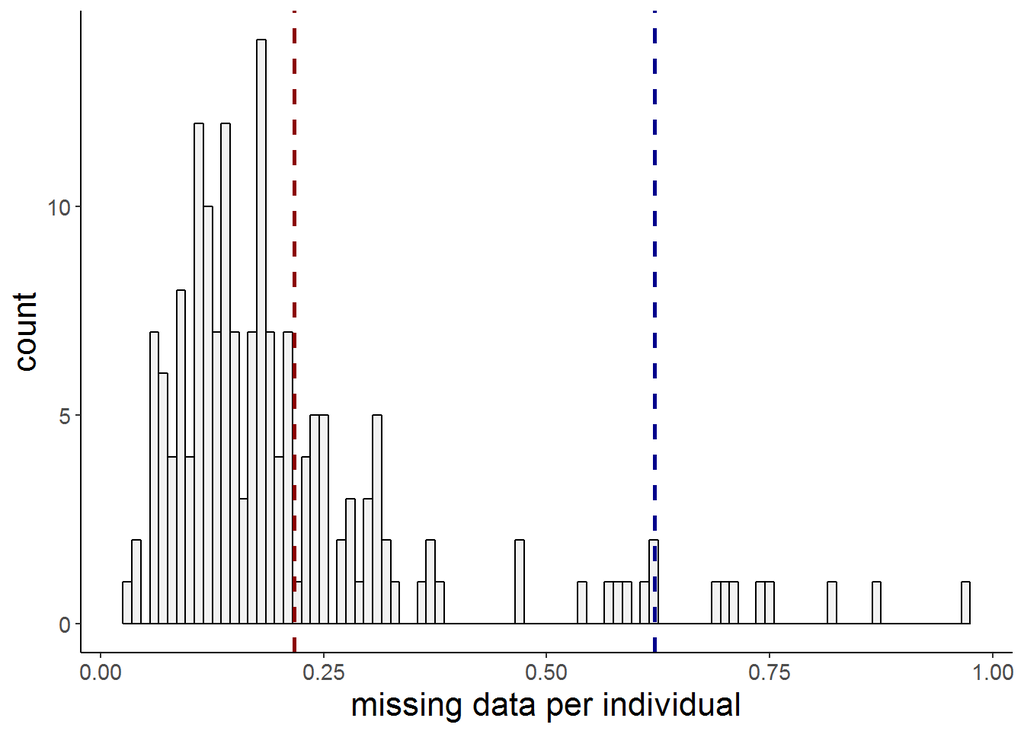

```r
ggplot(ind_stats_F2, aes(x = MISS_FamB.F2)) +
  geom_histogram(binwidth = .01, color = "black", fill = "grey95") +
  geom_vline(aes(xintercept = mean(MISS_FamB.F2, na.rm = TRUE)),
                 color = "darkred", linetype = "dashed", size = 1) +
  geom_vline(aes(xintercept = quantile(MISS_FamB.F2, .95)),
                 color = "darkblue", linetype = "dashed", size = 1) +
  labs(x = "missing data per individual") +
  theme_standard
```

Heterozygosity per individual across all SNP sites; the mean values for Fis is -0.1765041, the 95th % quantile is -0.04477 and the 5th % quantile is -0.59199:

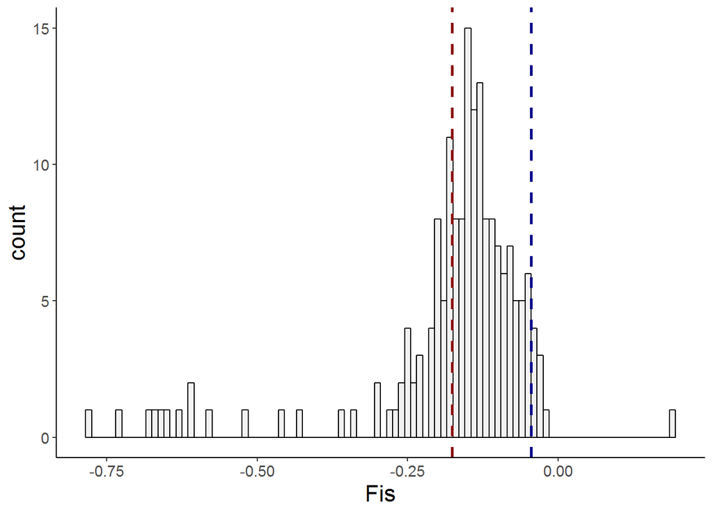

```r
ggplot(ind_stats_F2, aes(x = Fis_FamB.F2)) +
  geom_histogram(binwidth = .01, color = "black", fill = "grey95") +
  geom_vline(aes(xintercept = mean(Fis_FamB.F2, na.rm = TRUE)),
                 color = "darkred", linetype = "dashed", size = 1) +
  geom_vline(aes(xintercept = quantile(Fis_FamB.F2, .95)),
                 color = "darkblue", linetype = "dashed", size = 1) +
  labs(x = "Fis") +
  theme_standard
```

#### Filter 3: missing data (locus/indv) I

Filter loci with genotype call rate < 0.6

```
vcftools --vcf FamB.F2.recode.vcf --out FamB.F3a --max-missing 0.6 --recode --recode-INFO-all
vcftools --vcf FamB.F3a.recode.vcf --out FamB.F3a --missing
```

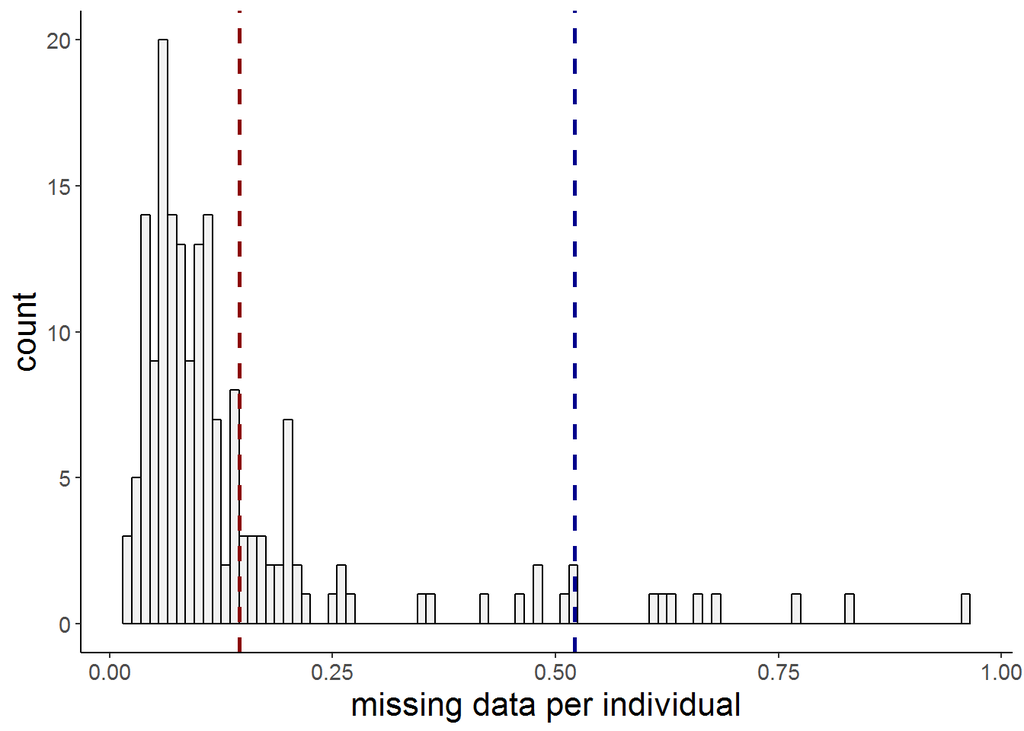

```r
imiss_F3 <- read.table("data/VCF/FamB.F3a.imiss",
                       header = TRUE, stringsAsFactors = FALSE)

ggplot(imiss_F3, aes(x = F_MISS)) +
  geom_histogram(binwidth = .01, color = "black", fill = "grey95") +
  geom_vline(aes(xintercept = mean(F_MISS, na.rm = TRUE)),
                 color = "darkred", linetype = "dashed", size = 1) +
  geom_vline(aes(xintercept = quantile(F_MISS, .95)),
                 color = "darkblue", linetype = "dashed", size = 1) +
  labs(x = "missing data per individual") +
  theme_standard
```

Remove individuals with more than 90% missing data

```
mawk -v x=0.9 '$5 > x' FamB.F3a.imiss | cut -f1 > lowDP.indv
vcftools --vcf FamB.F3a.recode.vcf --remove lowDP.indv --out FamB.F3b --recode --recode-INFO-all
```

#### Filter 4: minor allele frequency, mean minimum depth I

Remove loci with minor allele frequency < 0.01 and mean minimum depth (across all individuals) < 5

```
vcftools --vcf FamB.F3b.recode.vcf --out FamB.F4 --maf 0.01 --min-meanDP 5 --recode --recode-INFO-all
vcftools --vcf FamB.F4.recode.vcf --out FamB.F4 --missing-indv
vcftools --vcf FamB.F4.recode.vcf --out FamB.F4 --missing-site
vcftools --vcf FamB.F4.recode.vcf --out FamB.F4 --depth
vcftools --vcf FamB.F4.recode.vcf --out FamB.F4 --het
```

Assess individual quality by comparing levels of missing data and read depth.

```r
ind_stats_F4 <- read.ind.stats(dir = "data/VCF", vcf = "FamB.F4") %>%
  separate(INDV, into = c("SP", "LIB", "SAMPLE_ID"), sep = "_", remove = FALSE)
```

Mean read depth per individual across all SNP sites, the mean mean depth across all SNP sites is 53.9199101, the 5th % quantile is 8.304825:

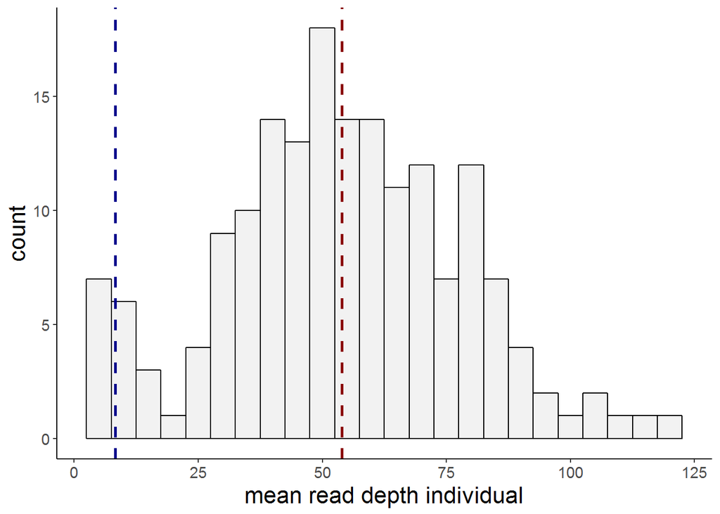

```r
ggplot(ind_stats_F4, aes(x = MEAN_DEPTH_FamB.F4)) +
  geom_histogram(binwidth = 5, color = "black", fill = "grey95") +
  geom_vline(aes(xintercept = mean(MEAN_DEPTH_FamB.F4, na.rm = TRUE)),
                 color = "darkred", linetype = "dashed", size = 1) +
  geom_vline(aes(xintercept = quantile(MEAN_DEPTH_FamB.F4, .05)),
                 color = "darkblue", linetype = "dashed", size = 1) +
  labs(x = "mean read depth individual") +
  theme_standard
```

Frequency of missing data per individual across all SNP sites; the mean mean depth across all individuals is NA, the 95th % quantile is NA:

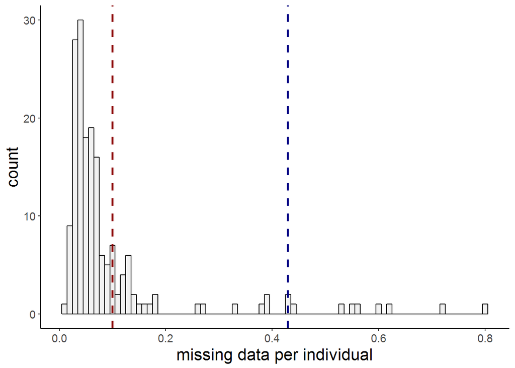

```r
ggplot(ind_stats_F4, aes(x = MISS_FamB.F4)) +
  geom_histogram(binwidth = .01, color = "black", fill = "grey95") +
  geom_vline(aes(xintercept = mean(MISS_FamB.F4, na.rm = TRUE)),
                 color = "darkred", linetype = "dashed", size = 1) +
  geom_vline(aes(xintercept = quantile(MISS_FamB.F4, .95)),
                 color = "darkblue", linetype = "dashed", size = 1) +
  labs(x = "missing data per individual") +
  theme_standard
```

Heterozygosity per individual across all SNP sites; the mean values for Fis is -0.1897826, the 95th % quantile is -0.0763435 and the 5th % quantile is -0.5941435:

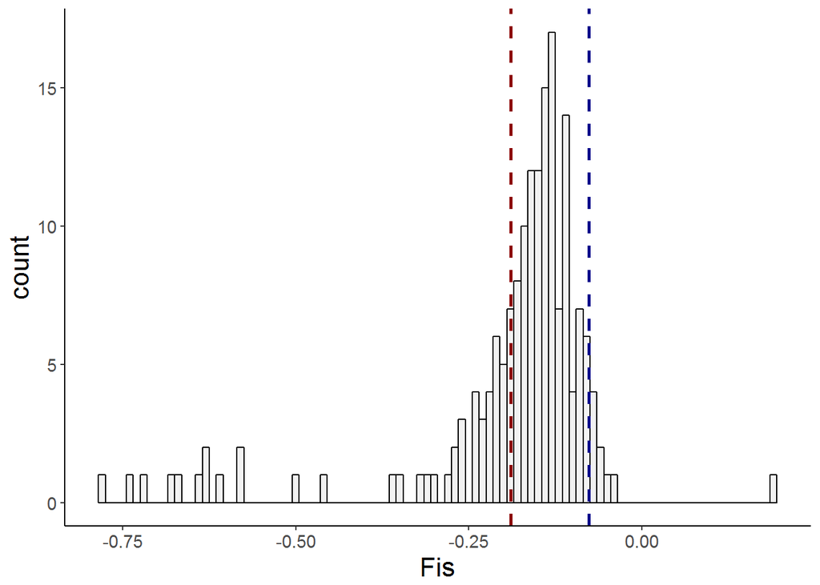

```r
ggplot(ind_stats_F4, aes(x = Fis_FamB.F4)) +
  geom_histogram(binwidth = .01, color = "black", fill = "grey95") +
  geom_vline(aes(xintercept = mean(Fis_FamB.F4, na.rm = TRUE)),
                 color = "darkred", linetype = "dashed", size = 1) +
  geom_vline(aes(xintercept = quantile(Fis_FamB.F4, .95)),
                 color = "darkblue", linetype = "dashed", size = 1) +
  labs(x = "Fis") +
  theme_standard
```

#### Filter 5: missing data (locus/indv) II

Remove loci with genotype call rate < 0.8

```
vcftools --vcf FamB.F4.recode.vcf --out FamB.F5a --max-missing 0.8  --recode --recode-INFO-all
vcftools --vcf FamB.F5a.recode.vcf --out FamB.F5a --missing
```

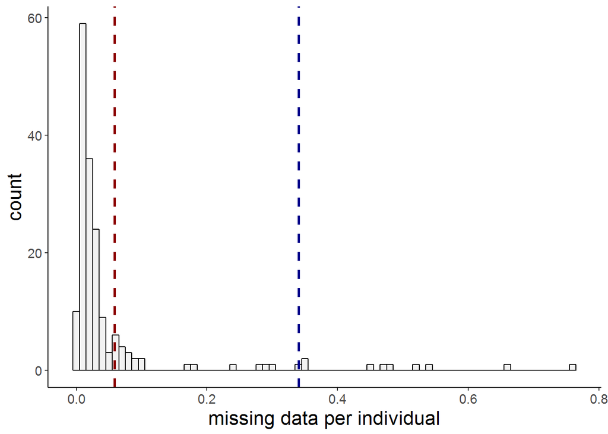

```r
imiss_F5 <- read.table("data/VCF/FamB.F5a.imiss",
                       header = TRUE, stringsAsFactors = FALSE)

ggplot(imiss_F5, aes(x = F_MISS)) +
  geom_histogram(binwidth = .01, color = "black", fill = "grey95") +
  geom_vline(aes(xintercept = mean(F_MISS, na.rm = TRUE)),
                 color = "darkred", linetype = "dashed", size = 1) +
  geom_vline(aes(xintercept = quantile(F_MISS, .95)),
                 color = "darkblue", linetype = "dashed", size = 1) +
  labs(x = "missing data per individual") +
  theme_standard
```

Remove individuals with > 75% missing data

```
mawk -v x=0.75 '$5 > x' FamB.F5a.imiss | cut -f1 > lowDP.indv
vcftools --vcf FamB.F5a.recode.vcf --remove lowDP.indv --recode --recode-INFO-all --out FamB.F5b
```

#### Filter 6: minor allele frequency, mean minimum depth II

Filter loci with minor allele frequency < 0.03 and mean minimum depth (across all individuals) < 10

```
vcftools --vcf FamB.F5b.recode.vcf --out FamB.F6 --maf 0.03 --recode --recode-INFO-all
vcftools --vcf FamB.F6.recode.vcf --out FamB.F6 --min-meanDP 10
vcftools --vcf FamB.F6.recode.vcf --out FamB.F6 --missing
vcftools --vcf FamB.F6.recode.vcf --out FamB.F6 --depth
vcftools --vcf FamB.F6.recode.vcf --out FamB.F6 --het
vcftools --vcf FamB.F6.recode.vcf --out FamB.F6 --missing-indv
vcftools --vcf FamB.F6.recode.vcf --out FamB.F6 --missing-site
```

Assess individual quality by comparing levels of missing data and read depth.

```r
ind_stats_F6 <- read.ind.stats(dir = "data/VCF", vcf = "FamB.F6") %>%
  separate(INDV, into = c("SP", "LIB", "SAMPLE_ID"), sep = "_", remove = FALSE)
```

Mean read depth per individual across all SNP sites, the mean mean depth across all SNP sites is 70.4745768, the 5th % quantile is 10.88328:

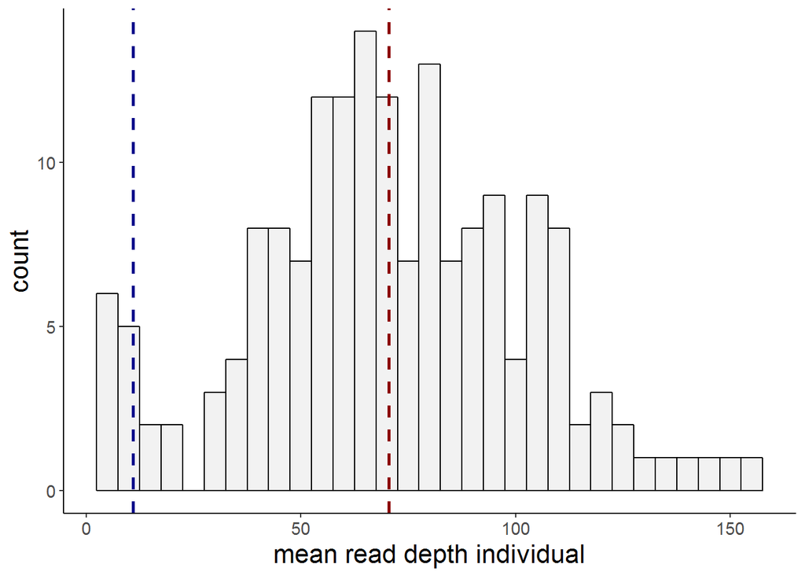

```r
# plot mean read depth per indv
ggplot(ind_stats_F6, aes(x = MEAN_DEPTH_FamB.F6)) +
  geom_histogram(binwidth = 5, color = "black", fill = "grey95") +
  geom_vline(aes(xintercept = mean(MEAN_DEPTH_FamB.F6, na.rm = TRUE)),
                 color = "darkred", linetype = "dashed", size = 1) +
  geom_vline(aes(xintercept = quantile(MEAN_DEPTH_FamB.F6, .05)),
                 color = "darkblue", linetype = "dashed", size = 1) +
  labs(x = "mean read depth individual") +
  theme_standard
```

Frequency of missing data per individual across all SNP sites; the mean mean depth across all individuals is 0.0468992, the 95th % quantile is 0.263346:

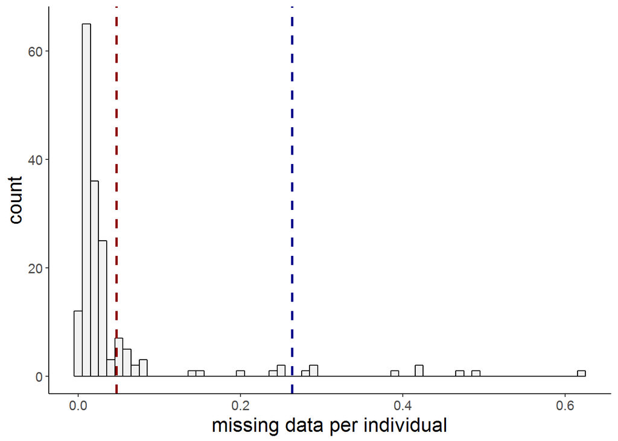

```r
ggplot(ind_stats_F6, aes(x = MISS_FamB.F6)) +
  geom_histogram(binwidth = .01, color = "black", fill = "grey95") +
  geom_vline(aes(xintercept = mean(MISS_FamB.F6, na.rm = TRUE)),
                 color = "darkred", linetype = "dashed", size = 1) +
  geom_vline(aes(xintercept = quantile(MISS_FamB.F6, .95)),
                 color = "darkblue", linetype = "dashed", size = 1) +
  labs(x = "missing data per individual") +
  theme_standard
```

Heterozygosity per individual across all SNP sites; the mean values for Fis is -0.2061564, the 95th % quantile is -0.109558 and the 5th % quantile is -0.631418:

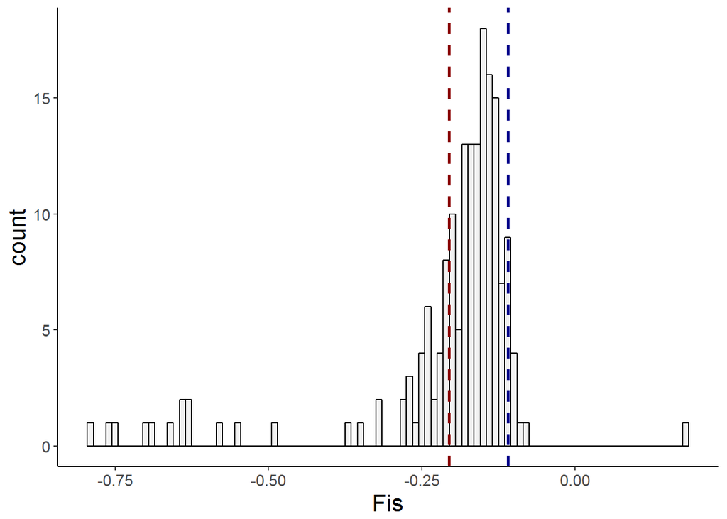

```r
ggplot(ind_stats_F6, aes(x = Fis_FamB.F6)) +
  geom_histogram(binwidth = .01, color = "black", fill = "grey95") +
  geom_vline(aes(xintercept = mean(Fis_FamB.F6, na.rm = TRUE)),
                 color = "darkred", linetype = "dashed", size = 1) +
  geom_vline(aes(xintercept = quantile(Fis_FamB.F6, .95)),
                 color = "darkblue", linetype = "dashed", size = 1) +
  labs(x = "Fis") +
  theme_standard
```

#### Filter 7: missing data (locus/indv) III

```
vcftools --vcf FamB.F6.recode.vcf --out FamB.F7a --max-missing 0.85 --recode --recode-INFO-all
vcftools --vcf FamB.F7a.recode.vcf --out FamB.F7a --missing
```

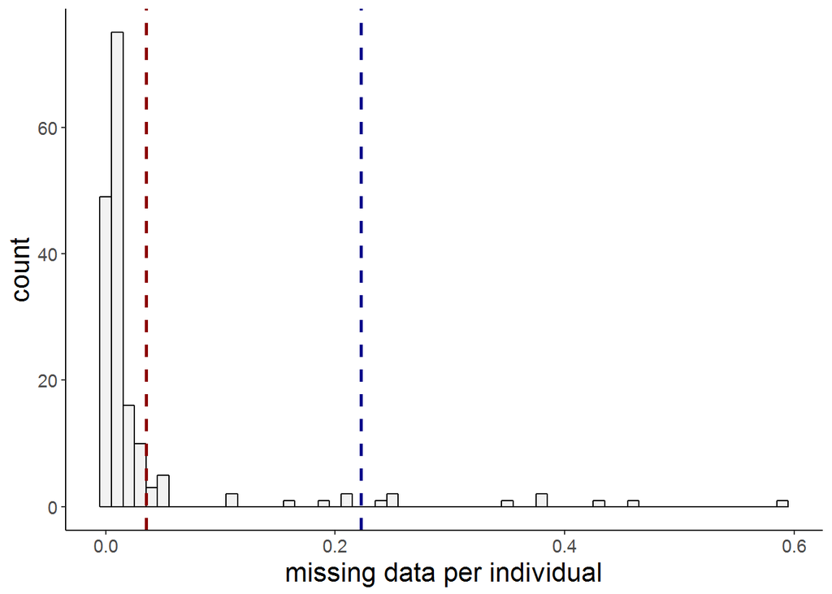

```r
imiss_F7 <- read.table("data/VCF/FamB.F7a.imiss",
                       header = TRUE, stringsAsFactors = FALSE)

ggplot(imiss_F7, aes(x = F_MISS)) +
  geom_histogram(binwidth = .01, color = "black", fill = "grey95") +
  geom_vline(aes(xintercept = mean(F_MISS, na.rm = TRUE)),
                 color = "darkred", linetype = "dashed", size = 1) +
  geom_vline(aes(xintercept = quantile(F_MISS, .95)),
                 color = "darkblue", linetype = "dashed", size = 1) +
  labs(x = "missing data per individual") +
  theme_standard
```

Remove individuals with > 65% missing data.

```
mawk -v x=0.65 '$5 > x' FamB.F7a.imiss | cut -f1 > lowDP.indv
vcftools --vcf FamB.F7a.recode.vcf --remove lowDP.indv --recode --recode-INFO-all --out FamB.F7b
```

#### Filter 8: Ratios of reference/alternate alleles, quality/depth, and mapping quality

```
vcffilter -s -f "AB > 0.2 & AB < 0.8 | AB < 0.01 | AB > 0.99" -s -g "QR > 0 | QA > 0" FamB.F7b.recode.vcf > FamB.F8a.vcf
```

Remove loci with quality/depth ratio < 0.2

```
vcffilter -s -f "QUAL / DP > 0.2" FamB.F8a.vcf > FamB.F8b.vcf
```

Remove loci based on ratio of mapping quality for reference and alternate allele, i.e. sites that have a high discrepancy between the mapping qualities of two alleles.

```
vcffilter -s -f "MQM / MQMR > 0.25 & MQM / MQMR < 1.75" FamB.F8b.vcf > FamB.F8c.vcf
```

Compare number of loci pre/post-filtering

```
mawk '!/#/' FamB.F7b.recode.vcf | wc -l
mawk '!/#/' FamB.F8a.vcf | wc -l
mawk '!/#/' FamB.F8b.vcf | wc -l
mawk '!/#/' FamB.F8c.vcf | wc -l
```

#### Filter 9: Loci with reads from both strands

```
vcffilter -f "SAF / SAR > 100 & SRF / SRR > 100 | SAR / SAF > 100 & SRR / SRF > 50" -s FamB.F8c.vcf > FamB.F9.vcf
```

Compare number of loci pre/post-filtering

```
mawk '!/#/' FamB.F9.vcf | wc -l
```

#### Filter 10: Properly paired status

Identify loci that only unpaired reads mapping to them - an artifact introduced due de novo reference assembly. Compare number of paired reads mapping the reference and the alternate alleles to identify discrepancy in the paired status for reads supporting reference and alternate alleles.

```
vcffilter -f "PAIRED > 0.05 & PAIREDR > 0.05 & PAIREDR / PAIRED < 1.75 & PAIREDR / PAIRED > 0.25 | PAIRED < 0.05 & PAIREDR < 0.05" -s FamB.F9.vcf > FamB.F10.vcf
```

Compare number of loci rep/post-filtering

```
mawk '!/#/' FamB.F10.vcf | wc -l
```

#### Filter 11: Maximum depth

Estimate the original number of individuals in the VCF file (INFO flags in filtered data set are are based on original number of individuals in data set):

```
grep -o -e 'NS=[0-9]*' FamB.F10.vcf | sed s/NS=//g | sort | tail -1
```

Create file with the original site depth and quality score for each site:

```
cut -f8 FamB.F10.vcf | grep -oe "DP=[0-9]*" | sed -s 's/DP=//g' > FamB.F10.DEPTH
mawk '!/#/'  FamB.F10.vcf | cut -f1,2,6 > FamB.F10.loci.qual
```

Calculate average depth and standard deviation:

```
mawk '{ sum += $1; n++ } END { if (n > 0) print sum / n; }' FamB.F10.DEPTH

mawk '{delta = $1 - avg; avg += delta / NR; mean2 += delta * ($1 - avg); } END { print sqrt(mean2 / NR); }' FamB.F10.DEPTH
```

```
paste FamB.F10.loci.qual FamB.F10.DEPTH | mawk -v x=24649.5 '$4 > x'| mawk '$3 < 2 * $4' > FamB.F10.lowQDloci
```

```
vcftools --vcf FamB.F10.vcf --remove-filtered NP --exclude-positions FamB.F10.lowQDloci --site-depth --out FamB.F10
cut -f3 FamB.F10.ldepth > FamB.F10.site.depth
mawk '!/D/' FamB.F10.site.depth | mawk -v x=175 '{print $1/x}' > FamB.meandepthpersite
```

Compare the distribution of mean depth per site averaged across individuals to determine cut-off value of sites with excessively high depth indicative of paralogs/multicopy loci.

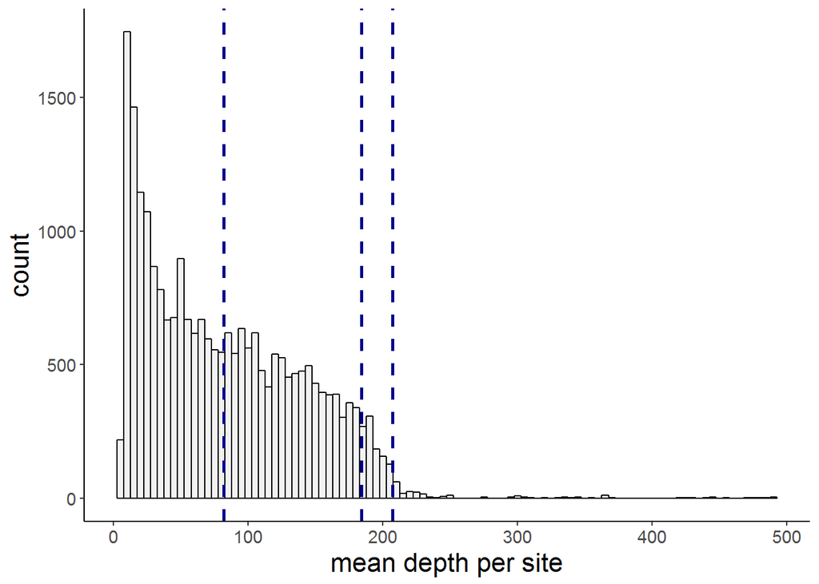

```r
# import mean depth per site
meandepthpersite <- read.table("data/VCF/FamB.meandepthpersite", header = FALSE)

# look at distribution
ggplot(meandepthpersite, aes(x = V1)) +
  geom_histogram(binwidth = 5, color = "black", fill = "grey95") +
  geom_vline(aes(xintercept = mean(V1, na.rm = TRUE)),
                 color = "darkblue", linetype = "dashed", size = 1) +
  geom_vline(aes(xintercept = quantile(meandepthpersite$V1, .95)),
                 color = "darkblue", linetype = "dashed", size = 1) +
  geom_vline(aes(xintercept = quantile(meandepthpersite$V1, .99)),
                 color = "darkblue", linetype = "dashed", size = 1) +
  labs(x = "mean depth per site") +
  theme_standard
```

Choose cut-off value = 250. Combine both depth filters to produce filtered data set.

```
vcftools --vcf  FamB.F10.vcf --max-meanDP 250 --exclude-positions FamB.F10.lowQDloci --recode --recode-INFO-all --out FamB.F11
```

#### Filter 12: Remove Indels

Remove Indels from data set.

```
vcfallelicprimitives FamB.F11.recode.vcf --keep-info --keep-geno > FamB.prim.vcf
vcftools --vcf FamB.prim.vcf --out FamB.F12 --remove-indels --recode --recode-INFO-all
```

#### Filter 13: Minor allele frequency

```
vcftools --vcf FamB.F12.recode.vcf --out FamB.F13 --maf 0.05 --recode --recode-INFO-all
vcftools --vcf FamB.F13.recode.vcf --out FamB.F13 --het
vcftools --vcf FamB.F13.recode.vcf --out FamB.F13 --missing-indv
vcftools --vcf FamB.F13.recode.vcf --out FamB.F13 --missing-site
vcftools --vcf FamB.F13.recode.vcf --out FamB.F13 --depth
```

**Assess individual quality**

Identify low quality individuals by comparing levels of missing data and read depth.

```r
ind_stats_F13 <- read.ind.stats(dir = "data/VCF", vcf = "FamB.F13") %>%
  separate(INDV, into = c("SP", "LIB", "SAMPLE_ID"), sep = "_", remove = FALSE)
```

Mean read depth per individual across all SNP sites, the mean mean depth across all SNP sites is 36.3007265, the 5th % quantile is 5.654238:

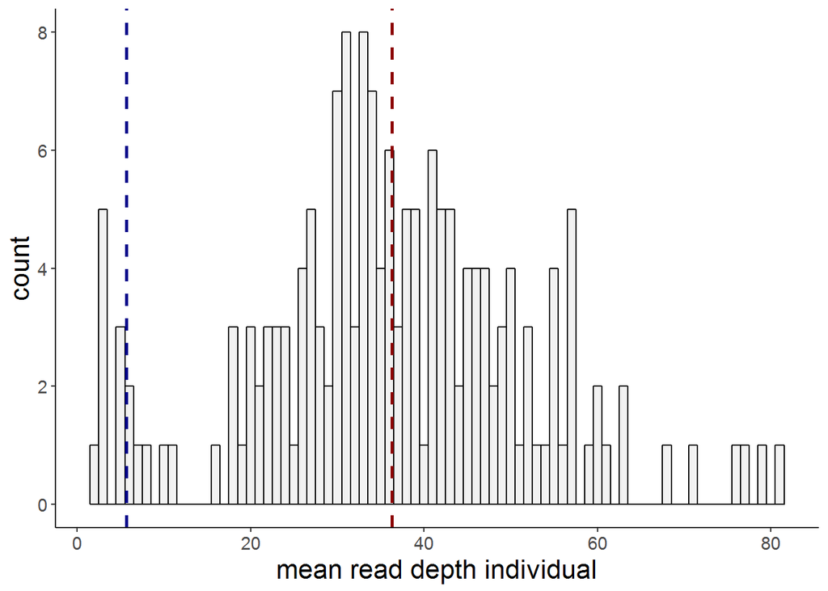

```r
ggplot(ind_stats_F13, aes(x = MEAN_DEPTH_FamB.F13)) +
  geom_histogram(binwidth = 1, color = "black", fill = "grey95") +
  geom_vline(aes(xintercept = mean(MEAN_DEPTH_FamB.F13, na.rm = TRUE)),
                 color = "darkred", linetype = "dashed", size = 1) +
  geom_vline(aes(xintercept = quantile(MEAN_DEPTH_FamB.F13, .05)),
                 color = "darkblue", linetype = "dashed", size = 1) +
  labs(x = "mean read depth individual") +
  theme_standard
```

Frequency of missing data per individual across all SNP sites; the mean mean depth across all individuals is 0.0484574, the 95th % quantile is 0.3217026:

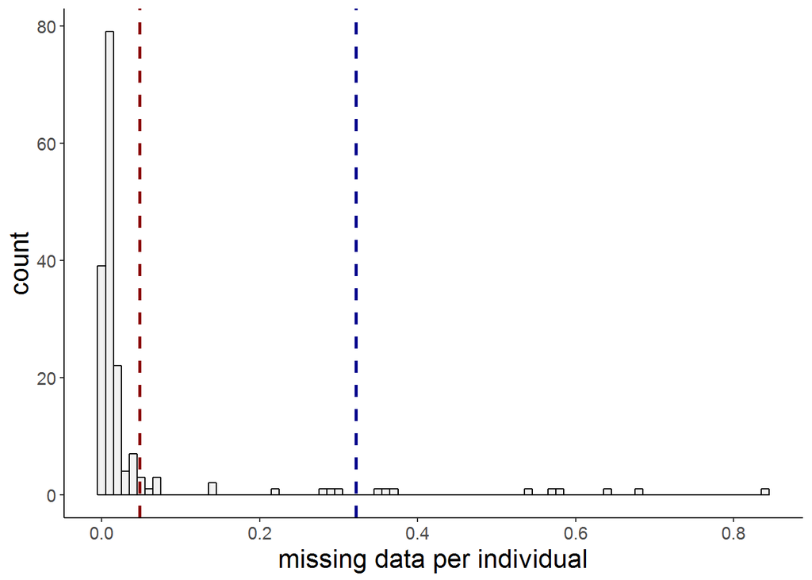

```r
ggplot(ind_stats_F13, aes(x = MISS_FamB.F13)) +
  geom_histogram(binwidth = .01, color = "black", fill = "grey95") +
  geom_vline(aes(xintercept = mean(MISS_FamB.F13, na.rm = TRUE)),
                 color = "darkred", linetype = "dashed", size = 1) +
  geom_vline(aes(xintercept = quantile(MISS_FamB.F13, .95)),
                 color = "darkblue", linetype = "dashed", size = 1) +
  labs(x = "missing data per individual") +
  theme_standard
```

Heterozygosity per individual across all SNP sites; the mean values for Fis is -0.1877523, the 95th % quantile is -0.077268 and the 5th % quantile is -0.46926:

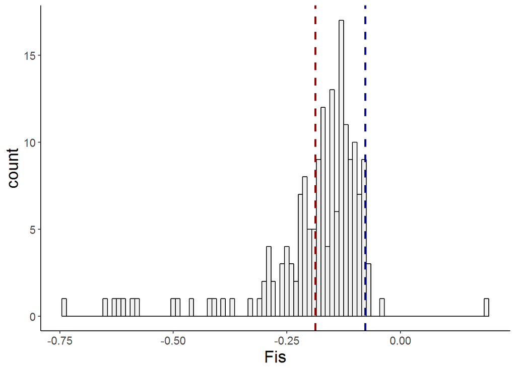

```r
ggplot(ind_stats_F13, aes(x = Fis_FamB.F13)) +
  geom_histogram(binwidth = .01, color = "black", fill = "grey95") +
  geom_vline(aes(xintercept = mean(Fis_FamB.F13, na.rm = TRUE)),
                 color = "darkred", linetype = "dashed", size = 1) +
  geom_vline(aes(xintercept = quantile(Fis_FamB.F13, .95)),
                 color = "darkblue", linetype = "dashed", size = 1) +
  labs(x = "Fis") +
  theme_standard
```

#### Filter 15: Missing data

Set final cut-off for genotype call rate to > 90%.

```
vcftools --vcf FamB.F13.recode.vcf --out FamB.F15a --max-missing 0.9 --recode --recode-INFO-all
vcftools --vcf FamB.F15a.recode.vcf --out FamB.F15a --missing-indv
```

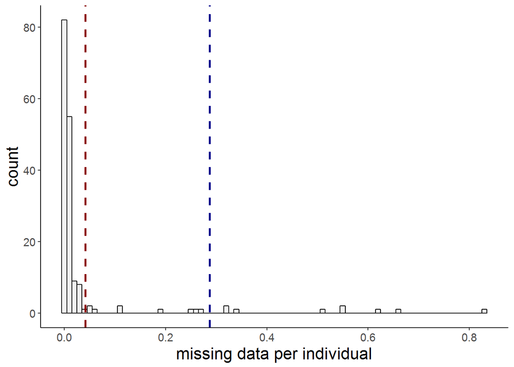

```r
imiss_F15 <- read.table("data/VCF/FamB.F15a.imiss",
                       header = TRUE, stringsAsFactors = FALSE, quote = NULL)

ggplot(imiss_F15, aes(x = F_MISS)) +
  geom_histogram(binwidth = .01, color = "black", fill = "grey95") +
  geom_vline(aes(xintercept = mean(F_MISS, na.rm = TRUE)),
                 color = "darkred", linetype = "dashed", size = 1) +
  geom_vline(aes(xintercept = quantile(F_MISS, .95)),
                 color = "darkblue", linetype = "dashed", size = 1) +
  labs(x = "missing data per individual") +
  theme_standard
```

Set final cut-off for allowable missing data per individual to < 50%.

```
mawk -v x=0.5 '$5 > x' FamB.F15a.imiss | cut -f1 > lowDP.indv
vcftools --vcf FamB.F15a.recode.vcf --out FamB.SNP --remove lowDP.indv --recode --recode-INFO-all

vcftools --vcf FamB.SNP.recode.vcf --out FamB.SNP --missing-indv
vcftools --vcf FamB.SNP.recode.vcf --out FamB.SNP --missing-site
vcftools --vcf FamB.SNP.recode.vcf --out FamB.SNP --site-mean-depth
vcftools --vcf FamB.SNP.recode.vcf --out FamB.SNP --depth
vcftools --vcf FamB.SNP.recode.vcf --out FamB.SNP --het
vcftools --vcf FamB.SNP.recode.vcf --out FamB.SNP --hardy
vcftools --vcf FamB.SNP.recode.vcf --out FamB.SNP --freq
```

# Haplotyping

## Create haplotypes FamA

Create list of individuals retained in final vcf file:

```
vcftools --vcf FamA.SNP.recode.vcf --out FamA --recode --recode-INFO-all
vcfsamplenames FamA.recode.vcf > FamA.individuals
```

Parental genotypes: * Father: SFL-A-M1 * Mother: SFL-A-F1

Use `SFL-FamA.individuals` to create `popmap` as a tab-separated file of individuals and their population designation, with one individual per line (make sure UNIX format). This file is needed to write the genepop file, if not provided the script will run through the process but not write a genepop file and place into same folder `rad_haplotyper.pl` will be run from.

```
nohup rad_haplotyper.pl -v FamA.recode.vcf -r reference.fasta -x 35 -d 10 -z 3 -m .5 -g FamA.gen -p FamA.popmap -t FamA.tsv -p1 SFL-1_SFL-A-F1 -p2 SFL-1_SFL-A-M1 -e
```

Copy files for analysis into `data/VCF/`-folder: * FamA_ind_stats.out * FamA_stats.out * FamA.gen * FamA.tsv

## Create haplotypes FamB

Parental genotypes: * Father: FamB-194 * Mother: FamB-059

Remove Male 2 (193) from vcf-file:

```
vcftools --vcf FamB.SNP.recode.vcf --out FamB --recode --recode-INFO-all --remove-indv FamB_FamB-193
```

Create list of individuals retained in final vcf file:

```
vcfsamplenames FamB.recode.vcf > FamB.individuals
```

Use `FamB.individuals` to create `FamB.popmap` as a tab-separated file of individuals and their population designation, with one individual per line (make sure UNIX format). This file is needed to write the genepop file, if not provided the script will run through the process but not write a genepop file and place into same folder `rad_haplotyper.pl` will be run from.

```
nohup rad_haplotyper.pl -v FamB.recode.vcf -r reference.fasta -x 35 -d 10 -z 3 -m .5 -g FamB.gen -p FamB.popmap -t FamB.tsv -p1 FamB_FamB-059 -p2 FamB_FamB-194 -e
```

Rename files and copy for analysis into `data/VCF/`-folder: * FamB_ind_stats.out * FamB_stats.out * FamB.gen * FamB.tsv

# Filter Haplotypes FamA

## Overview of haplotyping success

Create list of loci to filter from linkage map file (`*.tsv`-file), this can be done before converting to `*.raw` for analysis in r/QTL and onemap as the file format is one locus per row, then the genotype call in each individual.

```r
# import genepop file

# import tsv file
FamA_tsv <- read.delim("data/VCF/FamA.tsv", header = TRUE)

# remove all loci not called in at least 80% of individuals
FamA_tsv <- FamA_tsv %>%
  filter(Count > 127)

count(FamA_tsv, Count > 127)
```

```
## # A tibble: 1 × 2
##   `Count > 127`     n
##           <lgl> <int>
## 1          TRUE  4078
```

Remove loci not called in 70% of offspring (127 individuals) from `*.tsv`-file.

## Summary stats by locus

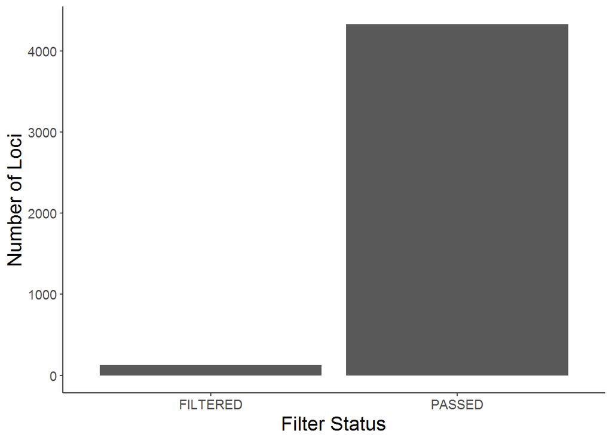

```r
# import stats files generated by haplotyper
hap_statsA <- read.hap.stats("data/VCF/FamA_stats.out")

hap_ind_statsA <- read.delim("data/VCF/FamA_ind_stats.out",
                            stringsAsFactors = FALSE)

# view comparison of filtered vs. passed loci
plot.filter.status(hap_statsA)
```

```r
# retain only "passed" loci
hap_statsA <- remove.filtered.haps(hap_statsA)
```

Overview of haplotyping stats per locus:

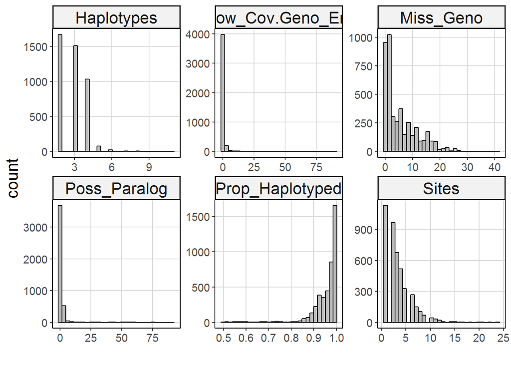

```r
plot.hap.stats(hap_statsA)
```

Overview of haplotyping stats per individual:

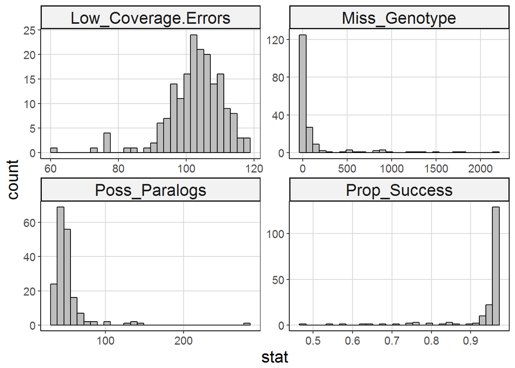

```r
plot.ind.hap.stats(hap_ind_statsA)
```

## Identify threshold values to filter data set

### Proportion of individuals haplotyped

```r
# summary of proportion of individuals haplotyped per locus
quantile(hap_statsA$Prop_Haplotyped, c(.5, .75, .85, .9, .95))
```

```
##   50%   75%   85%   90%   95%
## 0.978 0.995 0.995 1.000 1.000
```

```r
# number of loci called in >80% individuals
count(hap_statsA, Prop_Haplotyped < 0.8)
```

```
## # A tibble: 2 × 2
##   `Prop_Haplotyped < 0.8`     n
##                     <lgl> <int>
## 1                   FALSE  4205
## 2                    TRUE   129
```

```r
# create vector of loci to remove (choose cut-off)
Prop_Haplotyped <- filter.loci.prop_haplotyped(hap_statsA, 0.8)
```

### Possible paralogs per locus

Loci are flagged as possible paralogs for an individuals when more than the expected number of haplotypes based on the genotype call (homozygote, heterozygote) are detected.

Base threshold values on percent of individuals a locus was flagged as a potential paralog or based on distribution. 10% of individuals would mean that a locus was flagged in 18.3 individuals.

```r
# summary of count of possible paralogs
quantile(hap_statsA$Poss_Paralog, c(.5, .75, .85, .9, .95, 0.99))
```

```
## 50% 75% 85% 90% 95% 99%
##   0   1   2   2   3  30
```

```r
# number of loci with Poss_Paralogs in > 10 individuals
count(hap_statsA, Poss_Paralog > 18)
```

```
## # A tibble: 2 × 2
##   `Poss_Paralog > 18`     n
##                 <lgl> <int>
## 1               FALSE  4276
## 2                TRUE    58
```

```r
# create vector of loci to remove (choose cut-off)
Poss_Paralogs <- filter.loci.paralogs(hap_statsA, 18)
```

### Number of SNPs & Haplotypes per locus

Each locus varies in the number of SNPs detected which determines the number of haplotypes expected in that population. Loci can be excluded from the final data set by looking at the distribution of values to determine loci with an excessive amount of SNPs which could potentially be sequencing error or something similar.

```r
# summary of count of number of SNPs per locus
quantile(hap_statsA$Sites, c(.5, .75, .85, .9, .95))
```

```
## 50% 75% 85% 90% 95%
##   3   4   6   7   8
```

```r
quantile(hap_statsA$Haplotypes, c(.5, .75, .85, .9, .95))
```

```
## 50% 75% 85% 90% 95%
##   3   4   4   4   4
```

```r
# number of loci with number of SNPs > 10
count(hap_statsA, Sites > 5)
```

```
## # A tibble: 2 × 2
##   `Sites > 5`     n
##         <lgl> <int>
## 1       FALSE  3620
## 2        TRUE   714
```

```r
count(hap_statsA, Haplotypes > 7)
```

```
## # A tibble: 2 × 2
##   `Haplotypes > 7`     n
##              <lgl> <int>
## 1            FALSE  4326
## 2             TRUE     8
```

```r
# create vector of loci to remove (choose cut-off >5)
NoSNps <- filter.loci.noSNPs(hap_statsA, 5)
NoHaps <- filter.loci.NoHaps(hap_statsA, 7)
```

### Low Coverage/Genotyping Error

After combining SNPs at the same contig during the haplotyping process it is possible to observe fewer than the expected number of haplotypes. When this occurs, that is coded as missing data for that particular indvidual and the locus is flagged as a potential genotyping error or suffering from allelic drop out and the number of individuals with potential genotyping error/allelic dropout due to low coverage detected for a given locus is recorded. Cut-off value to remove locus if flagged as potential genotyping error in more than 10% of individuals is 18.3.

```r
# summary of count of possible genotyping errors
quantile(hap_statsA$Low_Cov.Geno_Err, c(.5, .75, .85, .9, .95))
```

```
## 50% 75% 85% 90% 95%
##   0   0   1   1   3
```

```r
# summary of count of possible genotyping errors
count(hap_statsA, Low_Cov.Geno_Err > 18)
```

```
## # A tibble: 2 × 2
##   `Low_Cov.Geno_Err > 18`     n
##                     <lgl> <int>
## 1                   FALSE  4243
## 2                    TRUE    91
```

```r
# create vector of loci to remove
Geno_Err <- filter.loci.geno_err(hap_statsA, 18)
```

Filter loci flagged as potential genotyping error in more than 10% of individuals (91 loci).

## Remove loci from tsv file

```r
# remove flagged loci
FamA_tsv_filtered <- FamA_tsv %>%
  filter(!Locus %in% NoSNps) %>%
  filter(!Locus %in% Geno_Err) %>%
  filter(!Locus %in% NoHaps) %>%
  filter(!Locus %in% Poss_Paralogs) %>%
  filter(!Parents == "aa/aa") %>%
  filter(!Parents == "--/--")

genotypes_FamA <- FamA_tsv_filtered %>%
  group_by(Parents) %>%
  summarise(n())

# write filtered tsv file
write.table(FamA_tsv_filtered, file = "data/VCF/FamA.filtered.tsv",
            quote = FALSE, row.names = FALSE)
```

# Filter haplotypes FamB

## Overview of haplotyping success

Create list of loci to filter from linkage map file (`*.tsv`-file), this can be done before converting to `*.raw` for analysis in r/QTL and onemap as the file format is one locus per row, then the genotype call in each individual.

```r
# import genepop file

# import tsv file
FamB_tsv <- read.delim("data/VCF/FamB.tsv", header = TRUE)

# remove all loci not called in at least 80% of individuals
FamB_tsv <- FamB_tsv %>%
  filter(Count > 122)

count(FamB_tsv, Count > 122)
```

```
## # A tibble: 1 × 2
##   `Count > 122`     n
##           <lgl> <int>
## 1          TRUE  2682
```

Remove loci not called in 70% of offspring (122) from `*.tsv`-file.

## Summary stats by locus

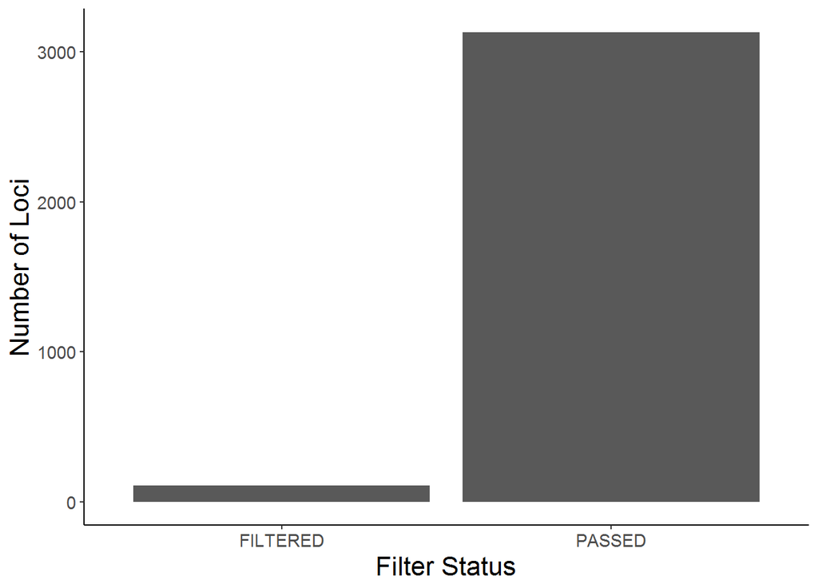

```r
# import stats files generated by haplotyper
hap_statsB <- read.hap.stats("data/VCF/FamB_stats.out")

hap_ind_statsB <- read.delim("data/VCF/FamB_ind_stats.out",
                            stringsAsFactors = FALSE)

# view comparison of filtered vs. passed loci
plot.filter.status(hap_statsB)
```

```r
# retain only "passed" loci
hap_statsB <- remove.filtered.haps(hap_statsB)
```

Overview of haplotyping stats per locus:

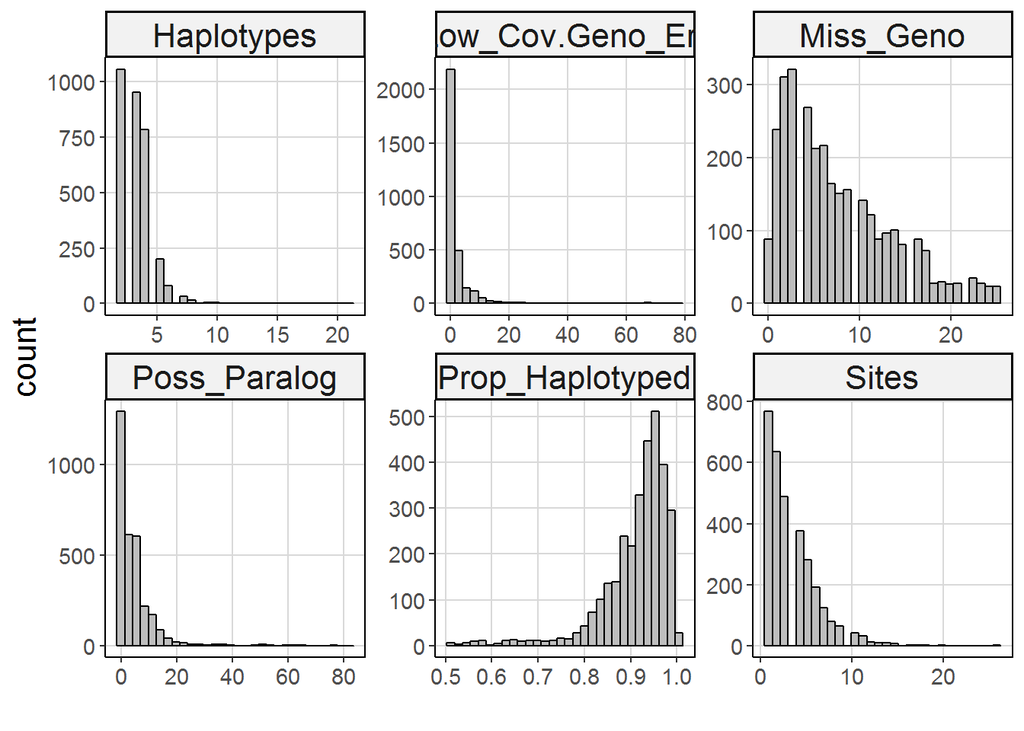

```r
plot.hap.stats(hap_statsB)
```

Overview of haplotyping stats per individual:

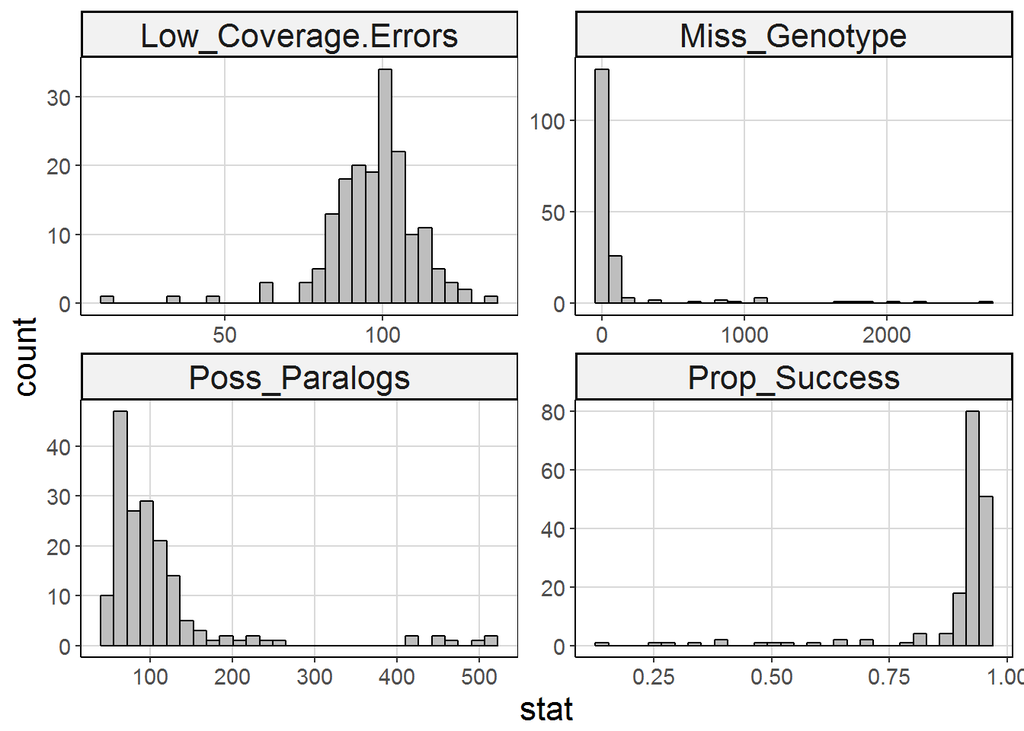

```r
plot.ind.hap.stats(hap_ind_statsB)
```

## Identify threshold values to filter data set

### Proportion of individuals haplotyped

```r
# summary of proportion of individuals haplotyped per locus
quantile(hap_statsB$Prop_Haplotyped, c(.5, .75, .85, .9, .95))
```

```
##   50%   75%   85%   90%   95%
## 0.930 0.959 0.971 0.983 0.988
```

```r
# number of loci called in >80% individuals
count(hap_statsB, Prop_Haplotyped < 0.8)
```

```
## # A tibble: 2 × 2
##   `Prop_Haplotyped < 0.8`     n
##                     <lgl> <int>
## 1                   FALSE  2941
## 2                    TRUE   191
```

```r
# create vector of loci to remove (choose cut-off)
Prop_Haplotyped <- filter.loci.prop_haplotyped(hap_statsB, 0.8)
```

### Possible paralogs per locus

Loci are flagged as possible paralogs for an individuals when more than the expected number of haplotypes based on the genotype call (homozygote, heterozygote) are detected.

Base threshold values on percent of individuals a locus was flagged as a potential paralog or based on distribution. 10% of individuals would mean that a locus was flagged in 17.2 individuals.

```r
# summary of count of possible paralogs
quantile(hap_statsB$Poss_Paralog, c(.5, .75, .85, .9, .95, 0.99))
```

```
## 50% 75% 85% 90% 95% 99%
##   3   7   9  11  15  40
```

```r
# number of loci with Poss_Paralogs in > 10 individuals
count(hap_statsB, Poss_Paralog > 17)
```

```
## # A tibble: 2 × 2
##   `Poss_Paralog > 17`     n
##                 <lgl> <int>
## 1               FALSE  3016
## 2                TRUE   116
```

```r
# create vector of loci to remove (choose cut-off)
Poss_Paralogs <- filter.loci.paralogs(hap_statsB, 17)
```

### Number of SNPs per locus

Each locus varies in the number of SNPs detected which determines the number of haplotypes expected in that population. Loci can be excluded from the final data set by looking at the distribution of values to determine loci with an excessive amount of SNPs which could potentially be sequencing error or something similar.

```r
# summary of count of number of SNPs per locus
quantile(hap_statsB$Sites, c(.5, .75, .85, .9, .95))
```

```
## 50% 75% 85% 90% 95%
##   3   5   6   7   9
```

```r
quantile(hap_statsB$Haplotypes, c(.5, .75, .85, .9, .95))
```

```
## 50% 75% 85% 90% 95%
##   3   4   4   5   5
```

```r
# number of loci with number of SNPs > 10
count(hap_statsB, Sites > 5)
```

```
## # A tibble: 2 × 2
##   `Sites > 5`     n
##         <lgl> <int>
## 1       FALSE  2551
## 2        TRUE   581
```

```r
count(hap_statsB, Haplotypes > 7)
```

```
## # A tibble: 2 × 2
##   `Haplotypes > 7`     n
##              <lgl> <int>
## 1            FALSE  3104
## 2             TRUE    28
```

```r
# create vector of loci to remove (choose cut-off >5)
NoSNps <- filter.loci.noSNPs(hap_statsB, 5)
NoHaps <- filter.loci.NoHaps(hap_statsB, 7)
```

### Low Coverage/Genotyping Error

After combining SNPs at the same contig during the haplotyping process it is possible to observe fewer than the expected number of haplotypes. When this occurs, that is coded as missing data for that particular indvidual and the locus is flagged as a potential genotyping error or suffering from allelic drop out and the number of individuals with potential genotyping error/allelic dropout due to low coverage detected for a given locus is recorded. Cut-off value to remove locus if flagged as potential genotyping error in more than 10% of individuals is 17.2.

```r
# summary of count of possible genotyping errors
quantile(hap_statsB$Low_Cov.Geno_Err, c(.5, .75, .85, .9, .95))
```

```
## 50% 75% 85% 90% 95%
##   0   2   4   6  11
```

```r
# summary of count of possible genotyping errors
count(hap_statsB, Low_Cov.Geno_Err > 17)
```

```
## # A tibble: 2 × 2
##   `Low_Cov.Geno_Err > 17`     n
##                     <lgl> <int>
## 1                   FALSE  3031
## 2                    TRUE   101
```

```r
# create vector of loci to remove
Geno_Err <- filter.loci.geno_err(hap_statsB, 17)
```

Filter loci flagged as potential genotyping error in more than 10% of individuals (101 loci).

## Remove loci from tsv file

```r
# remove flagged loci
FamB_tsv_filtered <- FamB_tsv %>%
  filter(!Locus %in% NoSNps) %>%
  filter(!Locus %in% Geno_Err) %>%
  filter(!Locus %in% NoHaps) %>%
  filter(!Locus %in% Poss_Paralogs) %>%
  filter(!Parents == "aa/aa") %>%
  filter(!Parents == "--/--")

genotypes_FamB <- FamB_tsv_filtered %>%
  group_by(Parents) %>%
  summarise(n())

# write filtered tsv file
write.table(FamB_tsv_filtered, file = "data/VCF/FamB.filtered.tsv",
            quote = FALSE, row.names = FALSE)
```

# Prepare final data set for mapping

Convert `*filtered.tsv`-file using `map_convert.pl`. Make sure that UNIX text file format before executing script.

## Family A

Create male and female map (mapmaker format) for analysis in `r/qtl`:

```
# male map
perl map_convert.pl -i FamA.filtered.tsv -n tsv -o FamA-M -u mm -s M -F SFL-A-F1 -M SFL-A-M1 -l 0.7 -c 0.7

# female map
perl map_convert.pl -i FamA.filtered.tsv -n tsv -o FamA-F -u mm -s F -F SFL-A-F1 -M SFL-A-M1 -l 0.7 -c 0.7
```

Rename and move outputfiles in `data/LINKMAP`:

- FamA-F.raw (individuals in file `FamA-F.ind`)
- FamA-M.raw (individuals in file `FamA-M.ind`)

Create onemap input file:

```
perl map_convert.pl -i FamA.filtered.tsv -n tsv -o FamA -u onemap -F SFL-A-F1 -M SFL-A-M1 -l 0.7 -c 0.7
```

Rename and move output files to `data/LINKMAP`:

- FamA.onemap (individuals in file `FamA.onemap.inds`)

## Family B

Create sex-specific input files for filtering in r/QTL:

```
# male map
perl map_convert.pl -i FamB.filtered.tsv -n tsv -o FamB-M -u mm -s M -F SFL-FamB.059 -M SFL-FamB.194 -l 0.7 -c 0.7

# female map
perl map_convert.pl -i FamB.filtered.tsv -n tsv -o FamB-F -u mm -s F -F SFL-FamB.059 -M SFL-FamB.194 -l 0.7 -c 0.7
```

Rename and move outputfiles in `data/LINKMAP`:

- FamB-F.raw (individuals in file `FamA-B.ind`)
- FamB-M.raw (individuals in file `FamA-B.ind`)

Create onemap input file:

```
perl map_convert.pl -i FamB.filtered.tsv -n tsv -o FamB -u onemap -F SFL-FamB.059 -M SFL-FamB.194 -l 0.7 -c 0.7
```

Rename and move output files to `data/LINKMAP`:

- FamB.onemap (individuals in file `FamB.onemap.inds`)